# CRISPRi PHENOMICS DATA ANALYSIS

Vaskar Mukherjee

2/3/2021

# IMPORT SCAN-O-MATIC RAW DATA

The phenotypic data generated in scan-o-matic screening in .csv format. We extract both the absolute and the normalized phenotypes.

The CRISPRi strains in the library were arrayed in 24 plates in 384 format. Each CRISPRi plate was subjected to two different condition (Basal and 150 mM of Acetic acid). Therefore, for each plate four different files are generated. All files generated in a single independent experimental round are stored in a single folder.

- **SOM_SCR_R001** : Raw data for round1
- **SOM_SCR_R002** : Raw data for round2

**ABSOLUTE DATA**

The **Absolute** dataset gives the extracted phenotypes without any spatial normalization

**NORMALIZED DATA**

The **Normalized** dataset is generated after removal of any spatial bias. This is in log2 scale and referred as Log Strain Coefficient (LSC) values

**FILE NAMING**

Each file is named with the plate identifier in such a way so that it can be easily called programmatically

Eg. Plate 1 absolute data in basal (Ctrl) condition have the following string  
*Ctrl1.phenotypes.Absolute*  
AND  
Plate 1 Normalized data in acetic acid (aa) stress have the string  
*aa1.phenotypes.Normalized*

## PURPOSE 1

At the end of this data import session, a single data.frame will be generated with the data of 24 plates. The whole dataset will be labeled with the strains attributes using the metadata key file (provided in the COMPILED_DATA folder). The data import below is shown for only Round2 dataset. Round1 can be generated modifying the folder location

**METADATA KEY FILE** : library_keyfile1536.csv

## IMPORTING THE METADATA FILE

```r
Metadata_CRISPRi <- read.csv("COMPILED_DATA/library_keyfile1536.csv", na.strings = "#N/A", stringsAsFactors = FALSE)
str(Metadata_CRISPRi)
```

```
## 'data.frame':    36864 obs. of  11 variables:
##  $ SL_No             : num  1 2 3 4 5 6 7 8 9 10 ...
##  $ gRNA_name         : chr  "FBP26-TRg-1" "FBP26-TRg-1" "HMI1-NRg-1" "HMI1-NRg-1" ...
##  $ Seq               : chr  "GCTTATCATACATTTACATC" "GCTTATCATACATTTACATC" "AAAAATTCTGACACATCACA" "AAAAATTCTGACACATCACA" ...
##  $ SOURCEPLATEID     : chr  "R2877.H.001" "R2877.H.001" "R2877.H.001" "R2877.H.001" ...
##  $ SOURCEDENSITY     : chr  "384A" "384A" "384A" "384A" ...
##  $ SOURCECOLONYCOLUMN: int  1 1 2 2 3 3 4 4 5 5 ...
##  $ SOURCECOLONYROW   : chr  "A" "A" "A" "A" ...
##  $ border            : logi  TRUE TRUE TRUE TRUE TRUE TRUE ...
##  $ GENE              : chr  "FBP26" "FBP26" "HMI1" "HMI1" ...
##  $ Control.gRNA      : int  0 0 0 0 0 0 0 0 0 0 ...
##  $ Location_1536     : chr  "A1" "A2" "A3" "A4" ...
```

## GENERATE BASAL **ABSOLUTE** DATASET

```r
m <- vector(mode = "character", length = 0)
file.names<-vector(mode = "character", length = 0)
temp_df<-data.frame()
data_Ctrl_Abs <- data.frame()
for(i in 1:24){
  m <- paste0("Ctrl", i, ".phenotypes.Absolute")
  file.names[i] <- dir("RAW_DATA/SOM_SCR_R002/", pattern = m, full.names = TRUE)
  temp_df <- read.csv(file.names[i], na.strings = "NoGrowth")
  data_Ctrl_Abs <- rbind(data_Ctrl_Abs, temp_df)
}
str(data_Ctrl_Abs)
```

```
## 'data.frame':    36864 obs. of  18 variables:
##  $ Plate                                   : int  0 0 0 0 0 0 0 0 0 0 ...
##  $ Row                                     : int  0 0 0 0 0 0 0 0 0 0 ...
##  $ Column                                  : int  0 1 2 3 4 5 6 7 8 9 ...
##  $ Phenotypes.InitialValue                 : num  80116 83495 92467 97104 99622 ...
##  $ Phenotypes.ExperimentBaseLine           : num  81419 84504 94039 98641 101354 ...
##  $ Phenotypes.ExperimentEndAverage         : num  8615209 6710686 6037319 5554230 5234758 ...
##  $ Phenotypes.ColonySize48h                : num  6487316 5329111 4946774 4684166 4440201 ...
##  $ Phenotypes.ChapmanRichardsParam2        : num  14.5 12.8 42.7 17.6 18.3 ...
##  $ Phenotypes.ChapmanRichardsParam3        : num  -2.74 -2.65 -2.58 -2.52 -2.47 ...
##  $ Phenotypes.ChapmanRichardsParamXtra     : num  16 16 16.2 16.3 16.3 ...
##  $ Phenotypes.ChapmanRichardsParam1        : num  1.95 1.89 1.84 1.8 1.77 ...
##  $ Phenotypes.ChapmanRichardsParam4        : num  -31.33 -31.47 -3.93 -2.78 -2.48 ...
##  $ Phenotypes.GenerationTimeStErrOfEstimate: num  0.012879 0.002174 0.000633 0.001667 0.000759 ...
##  $ Phenotypes.ExperimentGrowthYield        : num  8533790 6626182 5943280 5455589 5133404 ...
##  $ Phenotypes.GenerationTime               : num  2.53 2.48 2.51 2.56 2.53 ...
##  $ Phenotypes.ExperimentPopulationDoublings: num  6.73 6.31 6 5.82 5.69 ...
##  $ Phenotypes.ChapmanRichardsFit           : num  0.999 0.999 0.999 0.999 0.999 ...
##  $ Phenotypes.GenerationTimeWhen           : num  6.14 4.1 4.1 3.76 3.76 ...
```

Several phenotypes are extracted. However, the most useful for this study will be,

- Column No: 14 i.e. **Phenotypes.ExperimentGrowthYield**
- Column No: 15 i.e. **Phenotypes.GenerationTime**

Extract only this two column in the final data.frame  
Rename the column names to prevent any ambiguity

```r
data_Ctrl_Abs_Trim <- data_Ctrl_Abs[, 14:15]
colnames(data_Ctrl_Abs_Trim) <- c("CTRL_Y_ABS", "CTRL_GT_ABS")
str(data_Ctrl_Abs_Trim)
```

```
## 'data.frame':    36864 obs. of  2 variables:
##  $ CTRL_Y_ABS : num  8533790 6626182 5943280 5455589 5133404 ...
##  $ CTRL_GT_ABS: num  2.53 2.48 2.51 2.56 2.53 ...
```

## GENERATE ACETIC ACID **ABSOLUTE** DATASET

Following the same strategy as above

```r
m <- vector(mode = "character", length = 0)
file.names<-vector(mode = "character", length = 0)
temp_df<-data.frame()
data_AA_Abs <- data.frame()
for(i in 1:24){
  m <- paste0("aa", i, ".phenotypes.Absolute")
  file.names[i] <- dir("RAW_DATA/SOM_SCR_R002/", pattern = m, full.names = TRUE)
  temp_df <- read.csv(file.names[i], na.strings = "NoGrowth")
  data_AA_Abs <- rbind(data_AA_Abs, temp_df)
}
data_AA_Abs_Trim <- data_AA_Abs[, 14:15]
colnames(data_AA_Abs_Trim) <- c("AA_Y_ABS", "AA_GT_ABS")
```

## GENERATE BASAL **NORMALIZED** DATASET

```r
m <- vector(mode = "character", length = 0)
file.names<-vector(mode = "character", length = 0)
temp_df<-data.frame()
data_Ctrl_Norm <- data.frame()
for(i in 1:24){
  m <- paste0("Ctrl", i, ".phenotypes.Normalized")
  file.names[i] <- dir("RAW_DATA/SOM_SCR_R002/", pattern = m, full.names = TRUE)
  temp_df <- read.csv(file.names[i], na.strings = "NoGrowth")
  data_Ctrl_Norm <- rbind(data_Ctrl_Norm, temp_df)
}
str(data_Ctrl_Norm)
```

```
## 'data.frame':    36864 obs. of  8 variables:
##  $ Plate                                   : int  0 0 0 0 0 0 0 0 0 0 ...
##  $ Row                                     : int  0 0 0 0 0 0 0 0 0 0 ...
##  $ Column                                  : int  0 1 2 3 4 5 6 7 8 9 ...
##  $ Phenotypes.ExperimentGrowthYield        : num  0.755 0.39 0.233 0.484 0.396 ...
##  $ Phenotypes.GenerationTime               : num  0.0505 0.0204 0.0389 -0.0173 -0.0327 ...
##  $ Phenotypes.ExperimentPopulationDoublings: num  0.1907 0.0991 0.0272 0.113 0.0818 ...
##  $ Phenotypes.ExperimentBaseLine           : num  -0.0884 -0.0347 0.1195 0.0367 0.0758 ...
##  $ Phenotypes.ColonySize48h                : num  0.584 0.301 0.193 0.397 0.32 ...
```

The most useful for this study will be,

- Column No: 4 i.e. Phenotypes.ExperimentGrowthYield
- Column No: 5 i.e. Phenotypes.GenerationTime

Extract only this two column

```r
data_Ctrl_Norm_Trim <- data_Ctrl_Norm[, 4:5]
colnames(data_Ctrl_Norm_Trim) <- c("CTRL_Y_NORM", "CTRL_GT_NORM")
```

## GENERATE ACETIC ACID **NORMALIZED** DATASET

Same as above

```r
m <- vector(mode = "character", length = 0)
file.names<-vector(mode = "character", length = 0)
temp_df<-data.frame()
data_AA_Norm <- data.frame()
for(i in 1:24){
  m <- paste0("aa", i, ".phenotypes.Normalized")
  file.names[i] <- dir("RAW_DATA/SOM_SCR_R002/", pattern = m, full.names = TRUE)
  temp_df <- read.csv(file.names[i], na.strings = "NoGrowth")
  data_AA_Norm <- rbind(data_AA_Norm, temp_df)
}
data_AA_Norm_Trim <- data_AA_Norm[, 4:5]
colnames(data_AA_Norm_Trim) <- c("AA_Y_NORM", "AA_GT_NORM")
```

## COMBINE THE DATASETS TO OBTAIN FINAL DATAFRAME

Trimmed datasets are combined to obtain the final data.frame. The combined data frame is labeled as data from ROUND2

```r
R <- rep("2nd_round", 36864)
Round_ID <- data.frame(R, stringsAsFactors = FALSE)
whole_data_R2 <- cbind(Metadata_CRISPRi,
                       Round_ID,
                       data_Ctrl_Abs_Trim,
                       data_AA_Abs_Trim,
                       data_Ctrl_Norm_Trim,
                       data_AA_Norm_Trim)
colnames(whole_data_R2)[12] <- "Round_ID"
str(whole_data_R2)
```

```
## 'data.frame':    36864 obs. of  20 variables:
##  $ SL_No             : num  1 2 3 4 5 6 7 8 9 10 ...
##  $ gRNA_name         : chr  "FBP26-TRg-1" "FBP26-TRg-1" "HMI1-NRg-1" "HMI1-NRg-1" ...
##  $ Seq               : chr  "GCTTATCATACATTTACATC" "GCTTATCATACATTTACATC" "AAAAATTCTGACACATCACA" "AAAAATTCTGACACATCACA" ...
##  $ SOURCEPLATEID     : chr  "R2877.H.001" "R2877.H.001" "R2877.H.001" "R2877.H.001" ...
##  $ SOURCEDENSITY     : chr  "384A" "384A" "384A" "384A" ...
##  $ SOURCECOLONYCOLUMN: int  1 1 2 2 3 3 4 4 5 5 ...
##  $ SOURCECOLONYROW   : chr  "A" "A" "A" "A" ...
##  $ border            : logi  TRUE TRUE TRUE TRUE TRUE TRUE ...
##  $ GENE              : chr  "FBP26" "FBP26" "HMI1" "HMI1" ...
##  $ Control.gRNA      : int  0 0 0 0 0 0 0 0 0 0 ...
##  $ Location_1536     : chr  "A1" "A2" "A3" "A4" ...
##  $ Round_ID          : chr  "2nd_round" "2nd_round" "2nd_round" "2nd_round" ...
##  $ CTRL_Y_ABS        : num  8533790 6626182 5943280 5455589 5133404 ...
##  $ CTRL_GT_ABS       : num  2.53 2.48 2.51 2.56 2.53 ...
##  $ AA_Y_ABS          : num  2090439 2241914 1861277 1920070 1957912 ...
##  $ AA_GT_ABS         : num  8.92 8.43 9.19 8.91 8.87 ...
##  $ CTRL_Y_NORM       : num  0.755 0.39 0.233 0.484 0.396 ...
##  $ CTRL_GT_NORM      : num  0.0505 0.0204 0.0389 -0.0173 -0.0327 ...
##  $ AA_Y_NORM         : num  0.373 0.474 0.205 0.386 0.415 ...
##  $ AA_GT_NORM        : num  0.019 -0.0614 0.0621 -0.2135 -0.219 ...
```

## IMPORT RESULTS FROM ROUND1

The results from Round1 is already compiled to a .csv file in COMPILED_DATA folder **Results 1st Round** : 20190903_CRISPRi_Screen_aa_1st_round.csv

Import the dataset and label as data from ROUND1

```r
First_round <- read.csv("COMPILED_DATA/20190903_CRISPRi_Screen_aa_1st_round.csv",
                        na.strings = c("#N/A", "NoGrowth"),
                        stringsAsFactors = FALSE)
R <- rep("1st_round", 36864)
Round_ID <- data.frame(R, stringsAsFactors = FALSE)
whole_data_R1 <- cbind(Metadata_CRISPRi, Round_ID, First_round[, 12:19])
colnames(whole_data_R1)[12] <- "Round_ID"
str(whole_data_R1)
```

```
## 'data.frame':    36864 obs. of  20 variables:
##  $ SL_No             : num  1 2 3 4 5 6 7 8 9 10 ...
##  $ gRNA_name         : chr  "FBP26-TRg-1" "FBP26-TRg-1" "HMI1-NRg-1" "HMI1-NRg-1" ...
##  $ Seq               : chr  "GCTTATCATACATTTACATC" "GCTTATCATACATTTACATC" "AAAAATTCTGACACATCACA" "AAAAATTCTGACACATCACA" ...
##  $ SOURCEPLATEID     : chr  "R2877.H.001" "R2877.H.001" "R2877.H.001" "R2877.H.001" ...
##  $ SOURCEDENSITY     : chr  "384A" "384A" "384A" "384A" ...
##  $ SOURCECOLONYCOLUMN: int  1 1 2 2 3 3 4 4 5 5 ...
##  $ SOURCECOLONYROW   : chr  "A" "A" "A" "A" ...
##  $ border            : logi  TRUE TRUE TRUE TRUE TRUE TRUE ...
##  $ GENE              : chr  "FBP26" "FBP26" "HMI1" "HMI1" ...
##  $ Control.gRNA      : int  0 0 0 0 0 0 0 0 0 0 ...
##  $ Location_1536     : chr  "A1" "A2" "A3" "A4" ...
##  $ Round_ID          : chr  "1st_round" "1st_round" "1st_round" "1st_round" ...
##  $ CTRL_Y_ABS        : num  7046465 5380541 4841666 4517281 4209174 ...
##  $ CTRL_GT_ABS       : num  3.15 3.64 3.18 3.04 3.13 ...
##  $ AA_Y_ABS          : num  833657 844666 708042 734725 717147 ...
##  $ AA_GT_ABS         : num  13.1 13.6 14.5 14.7 13.6 ...
##  $ CTRL_Y_NORM       : num  0.899 0.51 0.358 0.565 0.463 ...
##  $ CTRL_GT_NORM      : num  -0.10076 0.10855 -0.08699 0.00504 0.0462 ...
##  $ AA_Y_NORM         : num  -0.362 -0.343 -0.598 -0.642 -0.677 ...
##  $ AA_GT_NORM        : num  0.273 0.331 0.423 0.425 0.313 ...
```

## COMBINE THE DATASETS of ROUND 1 AND 2

```r
whole_data_CRISPRi_aa <- rbind(whole_data_R1, whole_data_R2)
```

# SCAN-O-MATIC PHENOMICS ANALYSIS

In this study most of the downstream analysis was performed using the phenotype Generation_time(GT)

## PURPOSE 2

In this session, downstream data processing and statistical analysis of SCAN-O-MATIC raw output will be performed

## ESTIMATE THE LOG PHENOTYPIC INDEX (LPI) VALUES

LPI of strain is the difference of its normalized Generation_Time(GT) / Yield(Y) (LSC, see IMPORT SCAN-O-MATIC RAW DATA) on acetic acid stress plate to the basal condition. It gives a **RELATIVE** estimate of how a strain performed under acetic acid stress relative to the basal condition.

The **RELATIVE GENERATION TIME** i.e. LPI_GT = LSC_GT_Acetic_Acid - LSC_GT_Basal

```r
whole_data_CRISPRi_aa[, 21] <- whole_data_CRISPRi_aa[, 19]-whole_data_CRISPRi_aa[, 17]
whole_data_CRISPRi_aa[, 22] <- whole_data_CRISPRi_aa[, 20]-whole_data_CRISPRi_aa[, 18]
colnames(whole_data_CRISPRi_aa)[21] <- "LPI_Y"
colnames(whole_data_CRISPRi_aa)[22] <- "LPI_GT"
```

## PERFORM PLATE-WISE BATCH CORRECTION

Plate-wise batch correction was conducted by subtracting the median of LSC GT values of all the individual colonies on a plate from the individual LSC GT values of the colonies growing on that plate.

i.e. if strainX is growing in Basal condition on plate Z, the corrected LSC_GT value for strainX in the Basal condition is the following;

- LSC_GT_Basal_Corrected<sub>strainX</sub> = (LSC_GT_Basal<sub>strainX</sub>) - Median(LSC_GT Basal<sub>PlateZ</sub>)

```r
plate_ID <- as.character(unique(whole_data_CRISPRi_aa$SOURCEPLATEID))
whole_data_CRISPRi_aa_corrected <- whole_data_CRISPRi_aa
med_LogLSCctrl_RND1_GT <- vector(mode = "integer", length = 0)
med_LogLSCaa_RND1_GT <- vector(mode = "integer", length = 0)
med_LogLSCctrl_RND2_GT <- vector(mode = "integer", length = 0)
med_LogLSCaa_RND2_GT <- vector(mode = "integer", length = 0)
med_LogLSCctrl_RND1_Y <- vector(mode = "integer", length = 0)
med_LogLSCaa_RND1_Y <- vector(mode = "integer", length = 0)
med_LogLSCctrl_RND2_Y <- vector(mode = "integer", length = 0)
med_LogLSCaa_RND2_Y <- vector(mode = "integer", length = 0)

for(i in 1:24){
med_LogLSCctrl_RND1_GT[i] <- median(whole_data_CRISPRi_aa_corrected$CTRL_GT_NORM[which(whole_data_CRISPRi_aa_corrected$SOURCEPLATEID==plate_ID[i]
                                                                                       & !is.na(whole_data_CRISPRi_aa_corrected$CTRL_GT_NORM)
                                                                                         & whole_data_CRISPRi_aa_corrected$Round_ID=="1st_round")])

med_LogLSCaa_RND1_GT[i] <- median(whole_data_CRISPRi_aa_corrected$AA_GT_NORM[which(whole_data_CRISPRi_aa_corrected$SOURCEPLATEID==plate_ID[i]
                                                                                     & !is.na(whole_data_CRISPRi_aa_corrected$AA_GT_NORM)
                                                                                     & whole_data_CRISPRi_aa_corrected$Round_ID=="1st_round")])

med_LogLSCctrl_RND2_GT[i] <- median(whole_data_CRISPRi_aa_corrected$CTRL_GT_NORM[which(whole_data_CRISPRi_aa_corrected$SOURCEPLATEID==plate_ID[i]
                                                                                         & !is.na(whole_data_CRISPRi_aa_corrected$CTRL_GT_NORM)
                                                                                         & whole_data_CRISPRi_aa_corrected$Round_ID=="2nd_round")])

med_LogLSCaa_RND2_GT[i] <- median(whole_data_CRISPRi_aa_corrected$AA_GT_NORM[which(whole_data_CRISPRi_aa_corrected$SOURCEPLATEID==plate_ID[i]
                                                                                     & !is.na(whole_data_CRISPRi_aa_corrected$AA_GT_NORM)
                                                                                     & whole_data_CRISPRi_aa_corrected$Round_ID=="2nd_round")])

med_LogLSCctrl_RND1_Y[i] <- median(whole_data_CRISPRi_aa_corrected$CTRL_Y_NORM[which(whole_data_CRISPRi_aa_corrected$SOURCEPLATEID==plate_ID[i]
                                                                                       & !is.na(whole_data_CRISPRi_aa_corrected$CTRL_Y_NORM)
                                                                                       & whole_data_CRISPRi_aa_corrected$Round_ID=="1st_round")])

med_LogLSCaa_RND1_Y[i] <- median(whole_data_CRISPRi_aa_corrected$AA_Y_NORM[which(whole_data_CRISPRi_aa_corrected$SOURCEPLATEID==plate_ID[i]
                                                                                   & !is.na(whole_data_CRISPRi_aa_corrected$AA_Y_NORM)
                                                                                   & whole_data_CRISPRi_aa_corrected$Round_ID=="1st_round")])

med_LogLSCctrl_RND2_Y[i] <- median(whole_data_CRISPRi_aa_corrected$CTRL_Y_NORM[which(whole_data_CRISPRi_aa_corrected$SOURCEPLATEID==plate_ID[i]
                                                                                       & !is.na(whole_data_CRISPRi_aa_corrected$CTRL_Y_NORM)
                                                                                       & whole_data_CRISPRi_aa_corrected$Round_ID=="2nd_round")])

med_LogLSCaa_RND2_Y[i] <- median(whole_data_CRISPRi_aa_corrected$AA_Y_NORM[which(whole_data_CRISPRi_aa_corrected$SOURCEPLATEID==plate_ID[i]
                                                                                   & !is.na(whole_data_CRISPRi_aa_corrected$AA_Y_NORM)
                                                                                   & whole_data_CRISPRi_aa_corrected$Round_ID=="2nd_round")])

whole_data_CRISPRi_aa_corrected[which(whole_data_CRISPRi_aa_corrected$SOURCEPLATEID==plate_ID[i] &
                                          whole_data_CRISPRi_aa_corrected$Round_ID=="1st_round") , 23] <- whole_data_CRISPRi_aa_corrected[which(whole_data_CRISPRi_aa_corrected$SOURCEPLATEID==plate_ID[i] &
                                                                                                                                                  whole_data_CRISPRi_aa_corrected$Round_ID=="1st_round"), 17] - med_LogLSCctrl_RND1_Y[i]
  whole_data_CRISPRi_aa_corrected[which(whole_data_CRISPRi_aa_corrected$SOURCEPLATEID==plate_ID[i] &
                                          whole_data_CRISPRi_aa_corrected$Round_ID=="1st_round") , 24] <- whole_data_CRISPRi_aa_corrected[which(whole_data_CRISPRi_aa_corrected$SOURCEPLATEID==plate_ID[i] &
                                                                                                                                                  whole_data_CRISPRi_aa_corrected$Round_ID=="1st_round"), 18] - med_LogLSCctrl_RND1_GT[i]
  whole_data_CRISPRi_aa_corrected[which(whole_data_CRISPRi_aa_corrected$SOURCEPLATEID==plate_ID[i] &
                                          whole_data_CRISPRi_aa_corrected$Round_ID=="2nd_round") , 23] <- whole_data_CRISPRi_aa_corrected[which(whole_data_CRISPRi_aa_corrected$SOURCEPLATEID==plate_ID[i] &
                                                                                                                                                  whole_data_CRISPRi_aa_corrected$Round_ID=="2nd_round"), 17] - med_LogLSCctrl_RND2_Y[i]
  whole_data_CRISPRi_aa_corrected[which(whole_data_CRISPRi_aa_corrected$SOURCEPLATEID==plate_ID[i] &
                                          whole_data_CRISPRi_aa_corrected$Round_ID=="2nd_round") , 24] <- whole_data_CRISPRi_aa_corrected[which(whole_data_CRISPRi_aa_corrected$SOURCEPLATEID==plate_ID[i] &
                                                                                                                                                  whole_data_CRISPRi_aa_corrected$Round_ID=="2nd_round"), 18] - med_LogLSCctrl_RND2_GT[i]
  whole_data_CRISPRi_aa_corrected[which(whole_data_CRISPRi_aa_corrected$SOURCEPLATEID==plate_ID[i] &
                                          whole_data_CRISPRi_aa_corrected$Round_ID=="1st_round") , 25] <- whole_data_CRISPRi_aa_corrected[which(whole_data_CRISPRi_aa_corrected$SOURCEPLATEID==plate_ID[i] &
                                                                                                                                                  whole_data_CRISPRi_aa_corrected$Round_ID=="1st_round"), 19] - med_LogLSCaa_RND1_Y[i]
  whole_data_CRISPRi_aa_corrected[which(whole_data_CRISPRi_aa_corrected$SOURCEPLATEID==plate_ID[i] &
                                          whole_data_CRISPRi_aa_corrected$Round_ID=="1st_round") , 26] <- whole_data_CRISPRi_aa_corrected[which(whole_data_CRISPRi_aa_corrected$SOURCEPLATEID==plate_ID[i] &
                                                                                                                                                  whole_data_CRISPRi_aa_corrected$Round_ID=="1st_round"), 20] - med_LogLSCaa_RND1_GT[i]
  whole_data_CRISPRi_aa_corrected[which(whole_data_CRISPRi_aa_corrected$SOURCEPLATEID==plate_ID[i] &
                                          whole_data_CRISPRi_aa_corrected$Round_ID=="2nd_round") , 25] <- whole_data_CRISPRi_aa_corrected[which(whole_data_CRISPRi_aa_corrected$SOURCEPLATEID==plate_ID[i] &
                                                                                                                                                  whole_data_CRISPRi_aa_corrected$Round_ID=="2nd_round"), 19] - med_LogLSCaa_RND2_Y[i]
  whole_data_CRISPRi_aa_corrected[which(whole_data_CRISPRi_aa_corrected$SOURCEPLATEID==plate_ID[i] &
                                          whole_data_CRISPRi_aa_corrected$Round_ID=="2nd_round") , 26] <- whole_data_CRISPRi_aa_corrected[which(whole_data_CRISPRi_aa_corrected$SOURCEPLATEID==plate_ID[i] &
                                                                                                                                                  whole_data_CRISPRi_aa_corrected$Round_ID=="2nd_round"), 20] - med_LogLSCaa_RND2_GT[i]
}
```

## ESTIMATE THE BATCH CORRECTED LOG PHENOTYPIC INDEX (LPI) VALUES

Estimate the corrected LPI values (see ESTIMATE THE LOG PHENOTYPIC INDEX (LPI) VALUES) based on the corrected LSC values

i.e. LPI_GT<sub>corrected</sub> = LSC_GT_Acetic_Acid<sub>corrected</sub> - LSC_GT_Basal<sub>corrected</sub>

**Estimate the corrected LPI_Y**

```r
whole_data_CRISPRi_aa_corrected[, 27] <- whole_data_CRISPRi_aa_corrected[, 25] - whole_data_CRISPRi_aa_corrected[, 23]
```

**Estimate the corrected LPI_GT**

```r
whole_data_CRISPRi_aa_corrected[, 28] <- whole_data_CRISPRi_aa_corrected[, 26] - whole_data_CRISPRi_aa_corrected[, 24]
```

## SETTING THE NAMES OF THE NEW COLUMNS

```r
colnm <- colnames(whole_data_CRISPRi_aa)[17:22]
colnm <- paste0(colnm, "_CR")
colnames(whole_data_CRISPRi_aa_corrected)[23:28] <- colnm
str(whole_data_CRISPRi_aa_corrected)
```

```
## 'data.frame':    73728 obs. of  28 variables:
##  $ SL_No             : num  1 2 3 4 5 6 7 8 9 10 ...
##  $ gRNA_name         : chr  "FBP26-TRg-1" "FBP26-TRg-1" "HMI1-NRg-1" "HMI1-NRg-1" ...
##  $ Seq               : chr  "GCTTATCATACATTTACATC" "GCTTATCATACATTTACATC" "AAAAATTCTGACACATCACA" "AAAAATTCTGACACATCACA" ...
##  $ SOURCEPLATEID     : chr  "R2877.H.001" "R2877.H.001" "R2877.H.001" "R2877.H.001" ...
##  $ SOURCEDENSITY     : chr  "384A" "384A" "384A" "384A" ...
##  $ SOURCECOLONYCOLUMN: int  1 1 2 2 3 3 4 4 5 5 ...
##  $ SOURCECOLONYROW   : chr  "A" "A" "A" "A" ...
##  $ border            : logi  TRUE TRUE TRUE TRUE TRUE TRUE ...
##  $ GENE              : chr  "FBP26" "FBP26" "HMI1" "HMI1" ...
##  $ Control.gRNA      : int  0 0 0 0 0 0 0 0 0 0 ...
##  $ Location_1536     : chr  "A1" "A2" "A3" "A4" ...
##  $ Round_ID          : chr  "1st_round" "1st_round" "1st_round" "1st_round" ...
##  $ CTRL_Y_ABS        : num  7046465 5380541 4841666 4517281 4209174 ...
##  $ CTRL_GT_ABS       : num  3.15 3.64 3.18 3.04 3.13 ...
##  $ AA_Y_ABS          : num  833657 844666 708042 734725 717147 ...
##  $ AA_GT_ABS         : num  13.1 13.6 14.5 14.7 13.6 ...
##  $ CTRL_Y_NORM       : num  0.899 0.51 0.358 0.565 0.463 ...
##  $ CTRL_GT_NORM      : num  -0.10076 0.10855 -0.08699 0.00504 0.0462 ...
##  $ AA_Y_NORM         : num  -0.362 -0.343 -0.598 -0.642 -0.677 ...
##  $ AA_GT_NORM        : num  0.273 0.331 0.423 0.425 0.313 ...
##  $ LPI_Y             : num  -1.262 -0.854 -0.956 -1.207 -1.14 ...
##  $ LPI_GT            : num  0.374 0.223 0.51 0.42 0.266 ...
##  $ CTRL_Y_NORM_CR    : num  0.918 0.529 0.376 0.583 0.482 ...
##  $ CTRL_GT_NORM_CR   : num  -0.0877 0.1216 -0.074 0.0181 0.0592 ...
##  $ AA_Y_NORM_CR      : num  -0.0736 -0.0547 -0.3092 -0.3534 -0.3883 ...
##  $ AA_GT_NORM_CR     : num  0.19 0.248 0.34 0.342 0.229 ...
##  $ LPI_Y_CR          : num  -0.991 -0.583 -0.686 -0.937 -0.87 ...
##  $ LPI_GT_CR         : num  0.278 0.127 0.414 0.323 0.17 ...
```

## EXTRACT ONLY THE BATCH CORRECTED COLUMNS

```r
whole_data_CRISPRi_aa_2 <- whole_data_CRISPRi_aa_corrected[, c(1:16, 23:28)]
colnames(whole_data_CRISPRi_aa_2)[17:22] <- colnames(whole_data_CRISPRi_aa)[17:22]
str(whole_data_CRISPRi_aa_2)
```

```
## 'data.frame':    73728 obs. of  22 variables:
##  $ SL_No             : num  1 2 3 4 5 6 7 8 9 10 ...
##  $ gRNA_name         : chr  "FBP26-TRg-1" "FBP26-TRg-1" "HMI1-NRg-1" "HMI1-NRg-1" ...
##  $ Seq               : chr  "GCTTATCATACATTTACATC" "GCTTATCATACATTTACATC" "AAAAATTCTGACACATCACA" "AAAAATTCTGACACATCACA" ...
##  $ SOURCEPLATEID     : chr  "R2877.H.001" "R2877.H.001" "R2877.H.001" "R2877.H.001" ...
##  $ SOURCEDENSITY     : chr  "384A" "384A" "384A" "384A" ...
##  $ SOURCECOLONYCOLUMN: int  1 1 2 2 3 3 4 4 5 5 ...
##  $ SOURCECOLONYROW   : chr  "A" "A" "A" "A" ...
##  $ border            : logi  TRUE TRUE TRUE TRUE TRUE TRUE ...
##  $ GENE              : chr  "FBP26" "FBP26" "HMI1" "HMI1" ...
##  $ Control.gRNA      : int  0 0 0 0 0 0 0 0 0 0 ...
##  $ Location_1536     : chr  "A1" "A2" "A3" "A4" ...
##  $ Round_ID          : chr  "1st_round" "1st_round" "1st_round" "1st_round" ...
##  $ CTRL_Y_ABS        : num  7046465 5380541 4841666 4517281 4209174 ...
##  $ CTRL_GT_ABS       : num  3.15 3.64 3.18 3.04 3.13 ...
##  $ AA_Y_ABS          : num  833657 844666 708042 734725 717147 ...
##  $ AA_GT_ABS         : num  13.1 13.6 14.5 14.7 13.6 ...
##  $ CTRL_Y_NORM       : num  0.918 0.529 0.376 0.583 0.482 ...
##  $ CTRL_GT_NORM      : num  -0.0877 0.1216 -0.074 0.0181 0.0592 ...
##  $ AA_Y_NORM         : num  -0.0736 -0.0547 -0.3092 -0.3534 -0.3883 ...
##  $ AA_GT_NORM        : num  0.19 0.248 0.34 0.342 0.229 ...
##  $ LPI_Y             : num  -0.991 -0.583 -0.686 -0.937 -0.87 ...
##  $ LPI_GT            : num  0.278 0.127 0.414 0.323 0.17 ...
```

## CONSTRUCT A NEW DATA STRUCTURE

Construct a new data structure where data from each strain (have a unique guide-RNA) is in a separate row and the replicates from first and second round are side by side. Add also the mean, median and standard deviation statistics for each phenotype

### REMOVE ROWS WITH SPATIAL CONTROL STRAIN DATA

```r
Data_CRISPRi_aa <- subset(whole_data_CRISPRi_aa_2, whole_data_CRISPRi_aa_2$gRNA_name!="SP_Ctrl_CC23")
```

### CREATE A TABLE OF UNIQUE gRNA

```r
df_unique_sgRNA <- data.frame(table(Data_CRISPRi_aa$gRNA_name))
```

### ARRANGE THE DATA IN THE DESIRED FORMAT

```r
R1<-vector(mode = "integer", length = 0)
R2<-vector(mode = "integer", length = 0)
test2<-data.frame()
n<-nrow(df_unique_sgRNA)
for(i in 1:n){
  R1 <- which(Data_CRISPRi_aa$gRNA_name==df_unique_sgRNA$Var1[i] & Data_CRISPRi_aa$Round_ID=="1st_round")
  R2 <- which(Data_CRISPRi_aa$gRNA_name==df_unique_sgRNA$Var1[i] & Data_CRISPRi_aa$Round_ID=="2nd_round")
  test1 <- Data_CRISPRi_aa[c(R1, R2), ]
  test2[i, c(1:8)]<-test1[1, c(2:4, 6:7, 9:11)]
  test2[i, c(9:14)] <- test1$CTRL_GT_NORM
  test2[i, 15] <- mean(test1$CTRL_GT_NORM[1:3])
  test2[i, 16] <- mean(test1$CTRL_GT_NORM[4:6])
  test2[i, 17] <- sd(test1$CTRL_GT_NORM[1:3])
  test2[i, 18] <- sd(test1$CTRL_GT_NORM[4:6])
  test2[i, 19] <- mean(test1$CTRL_GT_NORM[1:6])
  test2[i, 20] <- median(test1$CTRL_GT_NORM[1:6])
  test2[i, 21] <- sd(test1$CTRL_GT_NORM[1:6])
  test2[i, c(22:27)] <- test1$AA_GT_NORM
  test2[i, 28] <- mean(test1$AA_GT_NORM[1:3])
  test2[i, 29] <- mean(test1$AA_GT_NORM[4:6])
  test2[i, 30] <- sd(test1$AA_GT_NORM[1:3])
  test2[i, 31] <- sd(test1$AA_GT_NORM[4:6])
  test2[i, 32] <- mean(test1$AA_GT_NORM[1:6])
  test2[i, 33] <- median(test1$AA_GT_NORM[1:6])
  test2[i, 34] <- sd(test1$AA_GT_NORM[1:6])
  test2[i, c(35:40)] <- test1$LPI_GT
  test2[i, 41] <- mean(test1$LPI_GT[1:3])
  test2[i, 42] <- mean(test1$LPI_GT[4:6])
  test2[i, 43] <- sd(test1$LPI_GT[1:3])
  test2[i, 44] <- sd(test1$LPI_GT[4:6])
  test2[i, 45] <- mean(test1$LPI_GT[1:6])
  test2[i, 46] <- median(test1$LPI_GT[1:6])
  test2[i, 47] <- sd(test1$LPI_GT[1:6])
  test2[i, c(48:53)] <- test1$CTRL_Y_NORM
  test2[i, 54] <- mean(test1$CTRL_Y_NORM[1:3])
  test2[i, 55] <- mean(test1$CTRL_Y_NORM[4:6])
  test2[i, 56] <- sd(test1$CTRL_Y_NORM[1:3])
  test2[i, 57] <- sd(test1$CTRL_Y_NORM[4:6])
  test2[i, 58] <- mean(test1$CTRL_Y_NORM[1:6])
  test2[i, 59] <- median(test1$CTRL_Y_NORM[1:6])
  test2[i, 60] <- sd(test1$CTRL_Y_NORM[1:6])
  test2[i, c(61:66)] <- test1$AA_Y_NORM
  test2[i, 67] <- mean(test1$AA_Y_NORM[1:3])
  test2[i, 68] <- mean(test1$AA_Y_NORM[4:6])
  test2[i, 69] <- sd(test1$AA_Y_NORM[1:3])
  test2[i, 70] <- sd(test1$AA_Y_NORM[4:6])
  test2[i, 71] <- mean(test1$AA_Y_NORM[1:6])
  test2[i, 72] <- median(test1$AA_Y_NORM[1:6])
  test2[i, 73] <- sd(test1$AA_Y_NORM[1:6])
  test2[i, c(74:79)] <- test1$LPI_Y
  test2[i, 80] <- mean(test1$LPI_Y[1:3])
  test2[i, 81] <- mean(test1$LPI_Y[4:6])
  test2[i, 82] <- sd(test1$LPI_Y[1:3])
  test2[i, 83] <- sd(test1$LPI_Y[4:6])
  test2[i, 84] <- mean(test1$LPI_Y[1:6])
  test2[i, 85] <- median(test1$LPI_Y[1:6])
  test2[i, 86] <- sd(test1$LPI_Y[1:6])
}
```

### ASSIGN COLUMN NAMES

Column names are already stored in a text times available in the **COMPILED_DATA** folder. Then store the data.frame under a new name.

```r
column_names <- read.table("COMPILED_DATA/Column_names.txt", header = FALSE, sep = "\t", as.is = TRUE)
colnames(test2) <- column_names$V1
Analysis_CRISPRi_aa_Complete <- test2
str(Analysis_CRISPRi_aa_Complete)
```

```
## 'data.frame':    9078 obs. of  86 variables:
##  $ gRNA_name          : chr  "AAR2-NRg-3" "AAR2-NRg-4" "AAR2-TRg-15" "AAR2-TRg-16" ...
##  $ Seq                : chr  "CCAGCGATAAGGAGGATCTT" "TGTGTCCTTTCTTCATCTCT" "AAAAGGAAAAAGTAATTAGG" "GTGAAAAGGAAAAAGTAATT" ...
##  $ SOURCEPLATEID      : chr  "R2877.H.023" "R2877.H.024" "R2877.H.023" "R2877.H.023" ...
##  $ SOURCECOLONYCOLUMN : int  5 21 22 20 21 18 6 7 9 8 ...
##  $ SOURCECOLONYROW    : chr  "O" "L" "P" "N" ...
##  $ GENE               : chr  "AAR2" "AAR2" "AAR2" "AAR2" ...
##  $ Control.gRNA       : int  0 0 0 0 0 0 0 0 0 0 ...
##  $ Location_1536      : chr  "AC9" "W41" "AE43" "AA39" ...
##  $ CTRL_GT_RND1_R1    : num  0.00397 0.00586 0.10456 -0.01142 0.0174 ...
##  $ CTRL_GT_RND1_R2    : num  -0.0086 0.00166 0.07118 0.00256 0.04094 ...
##  $ CTRL_GT_RND1_R3    : num  -0.000625 -0.043918 -0.009614 0.007969 -0.014018 ...
##  $ CTRL_GT_RND2_R1    : num  0.0431 -0.0336 0.0292 0.0381 0.0742 ...
##  $ CTRL_GT_RND2_R2    : num  -0.0165 0.00744 0.01433 0.06599 -0.02973 ...
##  $ CTRL_GT_RND2_R3    : num  0.03266 -0.04468 -0.04455 0.01994 -0.00924 ...
```

[output cut: 72 more lines]

## PERFORM STATISTICAL ANALYSIS

Multiple statistical method was applied to identify the best fit statistical model for this dataset. We start with the complete dataset and give it a new name to avoid distorting the original dataset.

```r
Analysis_Final <- Analysis_CRISPRi_aa_Complete
```

### METHOD 1

For **METHOD 1**, We hypothesized that the difference between the mean(µ) phenotypic performance of a specific CRISPRi strain (StrainX) in the two independent experimental rounds (n=2) to the mean phenotypic performance of all the CRISPRi strains that falls within the interquartile range (IQR) of the complete dataset would be zero, and any difference within the IQR to be just by chance.

**Null Hypothesis** : µ(µ<sub>LPI_GT_StrainX_Round1</sub>, µ<sub>LPI_GT_StrainX_Round2</sub>)- µ(InterquartileRange_LPI_GT) = 0

#### RECALCULATION OF SOME PHENOTYPIC PARAMETERS

In this method, we estimate the Mean / standard deviation (SD) of the LPI GT of Round 1 and Round 2 separately for each strain. When one/two of the three replicates of a strain in a round returned missing value (i.e. NA), then the mean / SD of LPI GT for that round is calculated by taking average of the non NA replicates. Therefore, excluding the missing values the mean and SD statistics were recalculated. We implemented a if else decision tree for this

- The mean and SD of Normalized generation time (**LSC GT mean**) at **Basal condition** re-calculation

```r
for(i in 1:nrow(Analysis_Final)){
  x1 <- as.numeric(Analysis_Final[i, 9:11][which(!is.na(Analysis_Final[i, 9:11]))])
  x2 <- as.numeric(Analysis_Final[i, 12:14][which(!is.na(Analysis_Final[i, 12:14]))])
  if(length(x1)==0){
    Analysis_Final$CTRL_GT_RND1_MEAN[i] <- NA
  } else{
    Analysis_Final$CTRL_GT_RND1_MEAN[i] <- as.numeric(mean(x1))
  }
  if(length(x2)==0){
    Analysis_Final$CTRL_GT_RND2_MEAN[i] <- NA
  } else{
    Analysis_Final$CTRL_GT_RND2_MEAN[i] <- as.numeric(mean(x2))
  }
  if(sum(is.na(c(Analysis_Final$CTRL_GT_RND1_MEAN[i], Analysis_Final$CTRL_GT_RND2_MEAN[i])))==0){
    Analysis_Final$CTRL_GT_RND1_2_MEAN[i] <- as.numeric(mean(c(Analysis_Final$CTRL_GT_RND1_MEAN[i], Analysis_Final$CTRL_GT_RND2_MEAN[i])))
    Analysis_Final[i, 87] <- as.numeric(sd(c(Analysis_Final$CTRL_GT_RND1_MEAN[i], Analysis_Final$CTRL_GT_RND2_MEAN[i])))
  } else{
    Analysis_Final$CTRL_GT_RND1_2_MEAN[i] <- NA
    Analysis_Final[i, 87] <- NA
  }
}
colnames(Analysis_Final)[87] <- "CTRL_GT_MEAN_RND1_2_SD"
```

- The mean and SD of Normalized generation time (**LSC GT mean**) at **150mM acetic acid** re-calculation

```r
for(i in 1:nrow(Analysis_Final)){
  x1 <- as.numeric(Analysis_Final[i, 22:24][which(!is.na(Analysis_Final[i, 22:24]))])
  x2 <- as.numeric(Analysis_Final[i, 25:27][which(!is.na(Analysis_Final[i, 25:27]))])
  if(length(x1)==0){
    Analysis_Final$AA_GT_RND1_MEAN[i] <- NA
  } else{
    Analysis_Final$AA_GT_RND1_MEAN[i] <- as.numeric(mean(x1))
  }
  if(length(x2)==0){
    Analysis_Final$AA_GT_RND2_MEAN[i] <- NA
  } else{
    Analysis_Final$AA_GT_RND2_MEAN[i] <- as.numeric(mean(x2))
  }
  if(sum(is.na(c(Analysis_Final$AA_GT_RND1_MEAN[i], Analysis_Final$AA_GT_RND2_MEAN[i])))==0){
    Analysis_Final$AA_GT_RND1_2_MEAN[i] <- as.numeric(mean(c(Analysis_Final$AA_GT_RND1_MEAN[i], Analysis_Final$AA_GT_RND2_MEAN[i])))
    Analysis_Final[i, 88] <- as.numeric(sd(c(Analysis_Final$AA_GT_RND1_MEAN[i], Analysis_Final$AA_GT_RND2_MEAN[i])))
  } else{
    Analysis_Final$AA_GT_RND1_2_MEAN[i] <- NA
    Analysis_Final[i, 88] <- NA
  }
}
colnames(Analysis_Final)[88] <- "AA_GT_MEAN_RND1_2_SD"
```

- The mean and SD of **RELATIVE** generation time (**LPI GT mean**) at **150mM acetic acid** re-calculation

```r
for(i in 1:nrow(Analysis_Final)){
  x1 <- as.numeric(Analysis_Final[i, 35:37][which(!is.na(Analysis_Final[i, 35:37]))])
  x2 <- as.numeric(Analysis_Final[i, 38:40][which(!is.na(Analysis_Final[i, 38:40]))])
  if(length(x1)==0){
    Analysis_Final$LPI_GT_RND1_MEAN[i] <- NA
  } else{
    Analysis_Final$LPI_GT_RND1_MEAN[i] <- as.numeric(mean(x1))
  }
  if(length(x2)==0){
    Analysis_Final$LPI_GT_RND2_MEAN[i] <- NA
  } else{
    Analysis_Final$LPI_GT_RND2_MEAN[i] <- as.numeric(mean(x2))
  }
  if(sum(is.na(c(Analysis_Final$LPI_GT_RND1_MEAN[i], Analysis_Final$LPI_GT_RND2_MEAN[i])))==0){
    Analysis_Final$LPI_GT_RND1_2_MEAN[i] <- as.numeric(mean(c(Analysis_Final$LPI_GT_RND1_MEAN[i], Analysis_Final$LPI_GT_RND2_MEAN[i])))
    Analysis_Final[i, 89] <- as.numeric(sd(c(Analysis_Final$LPI_GT_RND1_MEAN[i], Analysis_Final$LPI_GT_RND2_MEAN[i])))
  } else{
    Analysis_Final$LPI_GT_RND1_2_MEAN[i] <- NA
    Analysis_Final[i, 89] <- NA
  }
}
colnames(Analysis_Final)[89] <- "LPI_GT_MEAN_RND1_2_SD"
```

#### EXTRACT ALL LPI GT MEAN DATA POINTS WITHIN INTER-QUARTILE-RANGE (IQR)

BOX PLOT - MEAN RELATIVE GENERATION TIME (LPI GT)

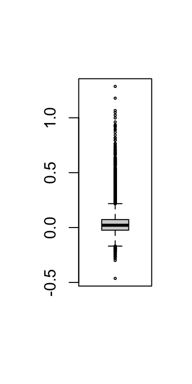

Figure 1: Boxplot of mean relative generation time (LPI GT) for all strains in the library

Display Box-plot statistics

```r
box_stat_LPI_GT_R1_2_mean$stats
```

```
##             [,1]
## [1,] -0.16933911
## [2,] -0.02428792
## [3,]  0.02084505
## [4,]  0.07255828
## [5,]  0.21771505
```

- 25th Percentile = -0.02428792
- 75th Percentile = 0.07255828

Therefore, extraction of the data points within IQR

```r
Intermediate_50 <- Analysis_Final$LPI_GT_RND1_2_MEAN[which(Analysis_Final$LPI_GT_RND1_2_MEAN>=-0.02428792
                                                           &Analysis_Final$LPI_GT_RND1_2_MEAN<=0.07255828)]
summary(Intermediate_50)
```

```
##       Min.    1st Qu.     Median       Mean    3rd Qu.       Max.
## -0.0242879 -0.0009547  0.0208382  0.0219831  0.0445144  0.0725032
```

#### ESTIMATE P-VALUE

P-value is estimated by Welch two sample two-sided t-test (an adaptation of Student’s t-test)

```r
for(i in 1:nrow(Analysis_Final)){
  if(sum(is.na(c(Analysis_Final$LPI_GT_RND1_MEAN[i], Analysis_Final$LPI_GT_RND2_MEAN[i])))==0){
    P_value <- t.test(Intermediate_50, c(Analysis_Final$LPI_GT_RND1_MEAN[i], Analysis_Final$LPI_GT_RND2_MEAN[i]))
    Analysis_Final[i, 90] <- P_value$p.value
  } else{
    Analysis_Final[i, 90] <- NA
  }
}
colnames(Analysis_Final)[90] <- "P_value_M1"
```

#### FALSE DISCOVERY RATE ADJUSTMENT OF P-VALUE

P-value adjustment by **BENJAMINI-HOCHBERG False Discovery Rate (FDR) method**

```r
Analysis_Final[which(!is.na(Analysis_Final$P_value_M1)), 91] <- p.adjust(Analysis_Final$P_value_M1[which(!is.na(Analysis_Final$P_value_M1))],
                                                                      method = "BH",
                                                                      n = length(Analysis_Final$P_value_M1[which(!is.na(Analysis_Final$P_value_M1))]))
colnames(Analysis_Final)[91] <- "P.adjusted_M1"
```

#### P-VALUE DISGNOSTICS FOR METHOD1

NUMBER OF SIGNIFICANT STRAINS

```r
length(Analysis_Final$P_value_M1[which(Analysis_Final$P_value_M1<=0.05)])
```

```
## [1] 434
```

```r
length(Analysis_Final$P.adjusted_M1[which(Analysis_Final$P.adjusted_M1<=0.05)])
```

```
## [1] 66
```

```r
length(Analysis_Final$P_value_M1[which(Analysis_Final$P_value_M1<=0.1)])
```

```
## [1] 842
```

```r
length(Analysis_Final$P.adjusted_M1[which(Analysis_Final$P.adjusted_M1<=0.1)])
```

```
## [1] 71
```

P-VALUE DIAGNOSTICS BY **HISTOGRAM ANALYSIS**

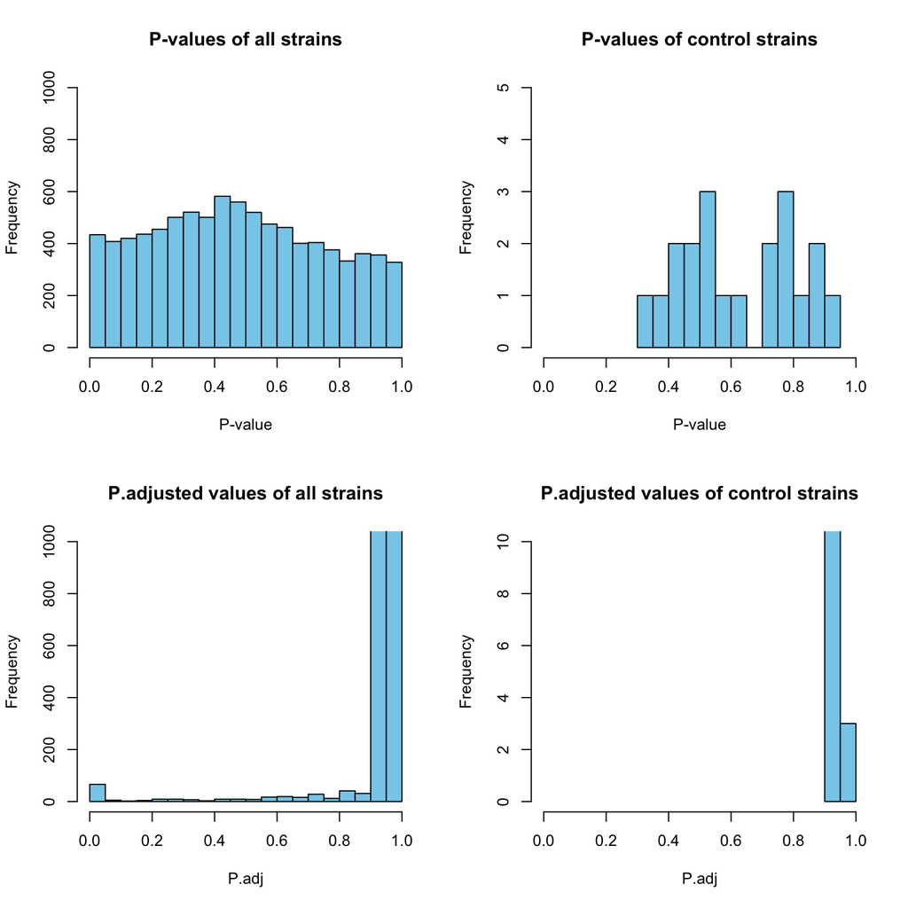

Figure 2: P-value diagnostic by histogram Method 1

#### CONCLUSIONS METHOD 1

Method 1 was too rigid as n=2. Even the smallest standard deviation between round1 and round2 is making an observation insignificant. This method puts the whole weightage on the variability between round1 and round2, not on the deviation from the mean of intermediate 50%. Therefore statistical method 1 was discarded after careful evaluation.

### METHOD 2

For **METHOD 2**, We hypothesized that the difference between the mean(µ) phenotypic performance (LPI GT) of a specific CRISPRi strain (StrainX) in a independent experimental round (each has three technical replicates, i.e. n=3) to the mean phenotypic performance of all the replicates of the CRISPRi control strains (with gRNA targeting no genetic locus in *S. cerevisiae*) in that respective screening round would be zero, and any difference within the CRISPRi control strain phenotypic performance range (LPI GT range) to be just by chance.

**Null Hypothesis** : µ<sub>StrainX</sub>(LPI_GT<sub>Replica1</sub>, LPI_GT<sub>Replica2</sub>, LPI_GT<sub>Replica3</sub>)- µ<sub>CRISPRi_Control_Strains</sub>(LPI_GT) = 0

In this method P-values for each strain were estimated for each round and only strain that showed significant performance in both round were considered for further analysis

First we clone the dataset in a new name to avoid any distortion down the line

```r
Analysis_Final_2 <- Analysis_Final
str(Analysis_Final_2)
```

```
## 'data.frame':    9078 obs. of  91 variables:
##  $ gRNA_name             : chr  "AAR2-NRg-3" "AAR2-NRg-4" "AAR2-TRg-15" "AAR2-TRg-16" ...
##  $ Seq                   : chr  "CCAGCGATAAGGAGGATCTT" "TGTGTCCTTTCTTCATCTCT" "AAAAGGAAAAAGTAATTAGG" "GTGAAAAGGAAAAAGTAATT" ...
##  $ SOURCEPLATEID         : chr  "R2877.H.023" "R2877.H.024" "R2877.H.023" "R2877.H.023" ...
##  $ SOURCECOLONYCOLUMN    : int  5 21 22 20 21 18 6 7 9 8 ...
##  $ SOURCECOLONYROW       : chr  "O" "L" "P" "N" ...
##  $ GENE                  : chr  "AAR2" "AAR2" "AAR2" "AAR2" ...
##  $ Control.gRNA          : int  0 0 0 0 0 0 0 0 0 0 ...
##  $ Location_1536         : chr  "AC9" "W41" "AE43" "AA39" ...
##  $ CTRL_GT_RND1_R1       : num  0.00397 0.00586 0.10456 -0.01142 0.0174 ...
##  $ CTRL_GT_RND1_R2       : num  -0.0086 0.00166 0.07118 0.00256 0.04094 ...
##  $ CTRL_GT_RND1_R3       : num  -0.000625 -0.043918 -0.009614 0.007969 -0.014018 ...
##  $ CTRL_GT_RND2_R1       : num  0.0431 -0.0336 0.0292 0.0381 0.0742 ...
##  $ CTRL_GT_RND2_R2       : num  -0.0165 0.00744 0.01433 0.06599 -0.02973 ...
##  $ CTRL_GT_RND2_R3       : num  0.03266 -0.04468 -0.04455 0.01994 -0.00924 ...
```

[output cut: 77 more lines]

#### EXTRACT CRISPRi CONTROL STRAINS DATA

Extract the CRISPRi-control strains LPI GT data from ROUND1 and ROUND2, respectively and store the output in two different vectors.

- **ROUND 1**

```r
CRISPRi_Ctrl_Round1 <- whole_data_CRISPRi_aa_2$LPI_GT[which(whole_data_CRISPRi_aa_2$Control.gRNA == 1
                                                            & whole_data_CRISPRi_aa_2$Round_ID=="1st_round")]
summary(CRISPRi_Ctrl_Round1)
```

```
##     Min.  1st Qu.   Median     Mean  3rd Qu.     Max.
## -0.06721  0.09108  0.16819  0.15842  0.20944  0.38829
```

- **ROUND 2**

```r
CRISPRi_Ctrl_Round2 <- whole_data_CRISPRi_aa_2$LPI_GT[which(whole_data_CRISPRi_aa_2$Control.gRNA == 1
                                                           & whole_data_CRISPRi_aa_2$Round_ID=="2nd_round")]
summary(CRISPRi_Ctrl_Round2)
```

```
##     Min.  1st Qu.   Median     Mean  3rd Qu.     Max.
## -0.21609 -0.07291 -0.02904 -0.01828  0.04256  0.15629
```

#### ESTIMATE P-VALUES FOR ROUND 1 AND 2

P-value is estimated by Welch two sample two-sided t-test (an adaptation of Student’s t-test)

```r
for(i in 1:nrow(Analysis_Final_2)){
  test1 <- t(Analysis_Final_2[i, 35:37])
  test2 <- t(Analysis_Final_2[i, 38:40])
  if(sum(!is.na(test1[, 1]))>=2){
    P_value_RND1 <- t.test(CRISPRi_Ctrl_Round1, test1[which(!is.na(test1[, 1]))])
    Analysis_Final_2[i, 92] <- P_value_RND1$p.value
  } else {
    Analysis_Final_2[i, 92] <- NA
  }
  if(sum(!is.na(test2[, 1]))>=2){
    P_value_RND2 <- t.test(CRISPRi_Ctrl_Round2, test2[which(!is.na(test2[, 1]))])
    Analysis_Final_2[i, 93] <- P_value_RND2$p.value
  } else {
    Analysis_Final_2[i, 93] <- NA
  }
}
colnames(Analysis_Final_2)[92:93] <- c("P_value_RND1_M2", "P_value_RND2_M2")
```

#### FALSE DISCOVERY RATE ADJUSTMENT OF P-VALUES FOR ROUND 1 AND 2

P-value adjustment by **BENJAMINI-HOCHBERG False Discovery Rate (FDR) method**

```r
Analysis_Final_2[which(!is.na(Analysis_Final_2$P_value_RND1_M2)), 94] <- p.adjust(Analysis_Final_2$P_value_RND1_M2[which(!is.na(Analysis_Final_2$P_value_RND1_M2))],
                                                                                  method = "BH",
                                                                                  n = length(Analysis_Final_2$P_value_RND1_M2[which(!is.na(Analysis_Final_2$P_value_RND1_M2))]))

Analysis_Final_2[which(!is.na(Analysis_Final_2$P_value_RND2_M2)), 95] <- p.adjust(Analysis_Final_2$P_value_RND2_M2[which(!is.na(Analysis_Final_2$P_value_RND2_M2))],
                                                                                  method = "BH",
                                                                                  n = length(Analysis_Final_2$P_value_RND2_M2[which(!is.na(Analysis_Final_2$P_value_RND2_M2))]))

colnames(Analysis_Final_2)[94:95] <- c("P.adjusted_RND1_M2", "P.adjusted_RND2_M2")
```

#### P-VALUE DISGNOSTICS FOR METHOD 2 : ROUND1

NUMBER OF SIGNIFICANT STRAINS

```r
length(Analysis_Final_2$P_value_RND1_M2[which(Analysis_Final_2$P_value_RND1_M2<=0.05)])
```

```
## [1] 4601
```

```r
length(Analysis_Final_2$P.adjusted_RND1_M2[which(Analysis_Final_2$P.adjusted_RND1_M2<=0.05)])
```

```
## [1] 3389
```

```r
length(Analysis_Final_2$P_value_RND1_M2[which(Analysis_Final_2$P_value_RND1_M2<=0.1)])
```

```
## [1] 5635
```

```r
length(Analysis_Final_2$P.adjusted_RND1_M2[which(Analysis_Final_2$P.adjusted_RND1_M2<=0.1)])
```

```
## [1] 4692
```

P-VALUE DIAGNOSTICS BY **HISTOGRAM ANALYSIS** ROUND 1

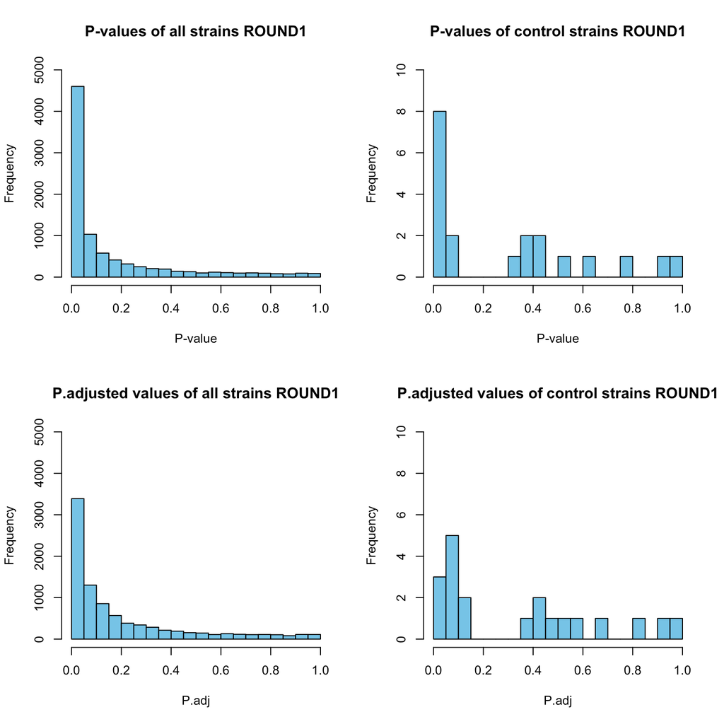

Figure 3: P-value diagnostic by histogram, Method 2, Round 1

#### P-VALUE DISGNOSTICS FOR METHOD 2 : ROUND2

NUMBER OF SIGNIFICANT STRAINS

```r
length(Analysis_Final_2$P_value_RND2_M2[which(Analysis_Final_2$P_value_RND2_M2<=0.05)])
```

```
## [1] 2304
```

```r
length(Analysis_Final_2$P.adjusted_RND2_M2[which(Analysis_Final_2$P.adjusted_RND2_M2<=0.05)])
```

```
## [1] 987
```

```r
length(Analysis_Final_2$P_value_RND2_M2[which(Analysis_Final_2$P_value_RND2_M2<=0.1)])
```

```
## [1] 3174
```

```r
length(Analysis_Final_2$P.adjusted_RND2_M2[which(Analysis_Final_2$P.adjusted_RND2_M2<=0.1)])
```

```
## [1] 1431
```

P-VALUE DIAGNOSTICS BY **HISTOGRAM ANALYSIS** ROUND 2

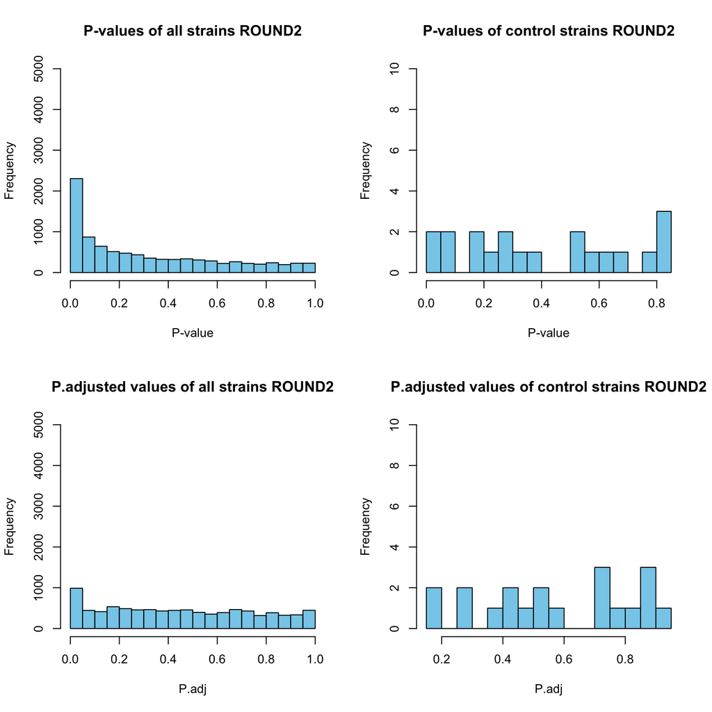

Figure 4: P-value diagnostic by histogram, Method 2, Round 2

#### CONCLUSIONS METHOD 2

It is a robust statistical method. However, one of the major problem with this method is setting different thresholds for p.adjusted values and LPI GT Mean for each round.

### METHOD 3 AND METHOD 4

For **METHOD 3**, We hypothesized that the difference between the mean(µ) phenotypic performance of a specific CRISPRi strain (StrainX) considering all technical replicates (3 in each) in the two independent experimental rounds (i.e. n=6) to the mean phenotypic performance of all the CRISPRi strains that falls within the interquartile range (IQR) of the complete dataset would be zero, and any difference within the IQR to be just by chance.

**Null Hypothesis** : µ<sub>StrainX</sub>(All_replicates_LPI_GT)- µ(InterquartileRange_LPI_GT) = 0

Additionally, we tested one final statistical model to determine significance of our observations

For **METHOD 4**, We hypothesized that the difference between the mean(µ) phenotypic performance of a specific CRISPRi strain (StrainX) considering all technical replicates (3 in each) in the two independent experimental rounds (i.e. n=6) to the mean phenotypic performance of all the CRISPRi control strains (with gRNA targeting no genetic locus in *S. cerevisiae*) would be zero, and any difference within the CRISPRi control strains phenotypic performance range (LPI GT range) to be just by chance.

**Null Hypothesis** : µ<sub>StrainX</sub>(All_replicates_LPI_GT) - µ<sub>CRISPRi_Control_Strains</sub>(LPI_GT) = 0

To ensure that we don’t distort the original dataset we clone the Analysis dataset in a new name

```r
Analysis_Final_3 <- Analysis_Final_2
```

#### EXTRACT ALL LPI GT DATA POINTS (INCLUDING ALL REPLICATES) WITHIN INTER-QUARTILE-RANGE (IQR)

Since we will consider all replicates this time, we will compare it with all replicates (NOT MEAN) that falls within IQR for Method 3. For this purpose, we extract the IQR dataset including all the replicate data for each strain. We will use the data.frame **Data_CRISPRi_aa** (see, REMOVE ROWS WITH SPATIAL CONTROL STRAIN DATA) to extract this numeric vector.

BOX PLOT - RELATIVE GENERATION TIME (LPI GT)

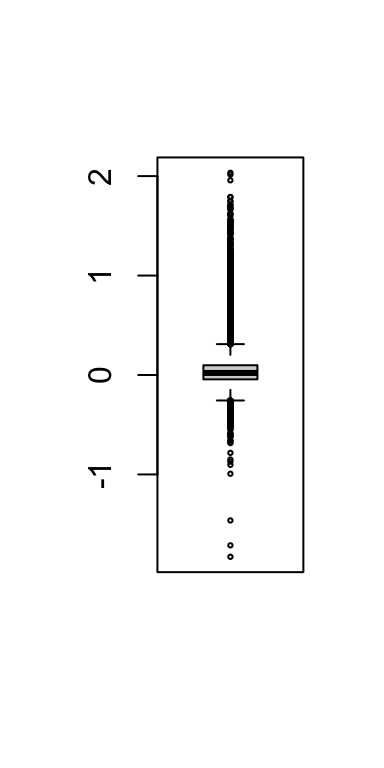

Figure 5: Boxplot of relative generation time (LPI GT) for all strains including all replicates in the library

Display Box-plot statistics

```r
boxplot_stat_LPI_GT$stats
```

```
##             [,1]
## [1,] -0.25630118
## [2,] -0.04373846
## [3,]  0.02045212
## [4,]  0.09804938
## [5,]  0.31050530
```

- 25th Percentile = -0.04373846
- 75th Percentile = 0.09804938

Therefore, extraction of the data points within IQR

```r
Intermediate_50_M3 <- Data_CRISPRi_aa$LPI_GT[which(Data_CRISPRi_aa$LPI_GT >=-0.04373846
                                                   &Data_CRISPRi_aa$LPI_GT<=0.09804938)]
summary(Intermediate_50_M3)
```

```
##     Min.  1st Qu.   Median     Mean  3rd Qu.     Max.
## -0.04374 -0.01004  0.02045  0.02236  0.05325  0.09805
```

#### EXTRACT CRISPRi CONTROL STRAINS DATA (ALL REPLICATES)

This time we extract all the replicate data (non the mean) of each of the CRISPRi control strains for the Method 4

```r
Crispri_control_M4 <- Data_CRISPRi_aa$LPI_GT[which(Data_CRISPRi_aa$Control.gRNA==1)]
summary(Crispri_control_M4)
```

```
##     Min.  1st Qu.   Median     Mean  3rd Qu.     Max.
## -0.21609 -0.03042  0.06889  0.07007  0.16628  0.38829
```

#### RECALCULATE THE LSC GT MEAN AT BASAL CONDITION AND LPI GT MEAN OF EACH STRAIN

We recalculate the above parameter taking all six replicates into account and excluding the missing values. For this purpose we use a if else decision tree. This means we get a LSC GT / LPI GT value if at-least 1 replicate managed to grow at a particular condition. Else it will return a missing value or NA

Additionally, we also create two columns that shows number of replicates of a strain managed to grow in basal condition (**n_CTRL**) and number of replicates in acetic acid condition (**n_LPI**)

```r
for(i in 1:nrow(Analysis_Final_3)){
  test1 <- t(Analysis_Final_3[i, 9:14])
  test2 <- t(Analysis_Final_3[i, 35:40])
  x1 <- sum(!is.na(test1[, 1]))
  x2 <- sum(!is.na(test2[, 1]))
  CTRL_GT_Mean_temp <- mean(test1[which(!is.na(test1[, 1]))])
  LPI_GT_Mean_temp <- mean(test2[which(!is.na(test2[, 1]))])
  Analysis_Final_3[i, 96] <- CTRL_GT_Mean_temp
  Analysis_Final_3[i, 97] <- x1
  Analysis_Final_3[i, 98] <- LPI_GT_Mean_temp
  Analysis_Final_3[i, 99] <- x2
}
colnames(Analysis_Final_3)[96:99] <- c("CTRL_GT_Mean_all", "n_CTRL", "LPI_GT_Mean_all", "n_LPI")
```

#### ESTIMATE P-VALUES FOR METHOD 3 AND 4

P-value is estimated by Welch two sample two-sided t-test (an adaptation of Student’s t-test)

```r
for(i in 1:nrow(Analysis_Final_3)){
  test <- t(Analysis_Final_3[i, 35:40])
  x <- sum(!is.na(test[, 1]))
  if(x>2){
    P.value_temp_M3 <- t.test(Intermediate_50_M3, test[which(!is.na(test[, 1]))])
    P.value_temp_M4 <- t.test(Crispri_control_M4, test[which(!is.na(test[, 1]))])
    Analysis_Final_3[i, 100] <- P.value_temp_M3$p.value
    Analysis_Final_3[i, 101] <- P.value_temp_M4$p.value
  } else {
    Analysis_Final_3[i, 100] <- NA
    Analysis_Final_3[i, 101] <- NA
  }
}
colnames(Analysis_Final_3)[100:101] <- c("P.value_M3", "P.value_M4")
```

#### FALSE DISCOVERY RATE ADJUSTMENT OF P-VALUES FOR METHOD 3 AND 4

P-value adjustment by **BENJAMINI-HOCHBERG False Discovery Rate (FDR) method**

```r
Analysis_Final_3[which(!is.na(Analysis_Final_3$P.value_M3)), 102] <- p.adjust(Analysis_Final_3$P.value_M3[which(!is.na(Analysis_Final_3$P.value_M3))],
                                                                              method = "BH",
                                                                              n = length(Analysis_Final_3$P.value_M3[which(!is.na(Analysis_Final_3$P.value_M3))]))
Analysis_Final_3[which(!is.na(Analysis_Final_3$P.value_M4)), 103] <- p.adjust(Analysis_Final_3$P.value_M4[which(!is.na(Analysis_Final_3$P.value_M4))],
                                                                              method = "BH",
                                                                              n = length(Analysis_Final_3$P.value_M4[which(!is.na(Analysis_Final_3$P.value_M4))]))
colnames(Analysis_Final_3)[102:103] <- c("P.adjusted_M3", "P.adjusted_M4")
```

#### P-VALUE DISGNOSTICS FOR METHOD 3

NUMBER OF SIGNIFICANT STRAINS

```r
length(Analysis_Final_3$P.value_M3[which(Analysis_Final_3$P.value_M3<=0.05)])
```

```
## [1] 2468
```

```r
length(Analysis_Final_3$P.adjusted_M3[which(Analysis_Final_3$P.adjusted_M3<=0.05)])
```

```
## [1] 514
```

```r
length(Analysis_Final_3$P.value_M3[which(Analysis_Final_3$P.value_M3<=0.1)])
```

```
## [1] 3392
```

```r
length(Analysis_Final_3$P.adjusted_M3[which(Analysis_Final_3$P.adjusted_M3<=0.1)])
```

```
## [1] 1258
```

P-VALUE DIAGNOSTICS BY **HISTOGRAM ANALYSIS**

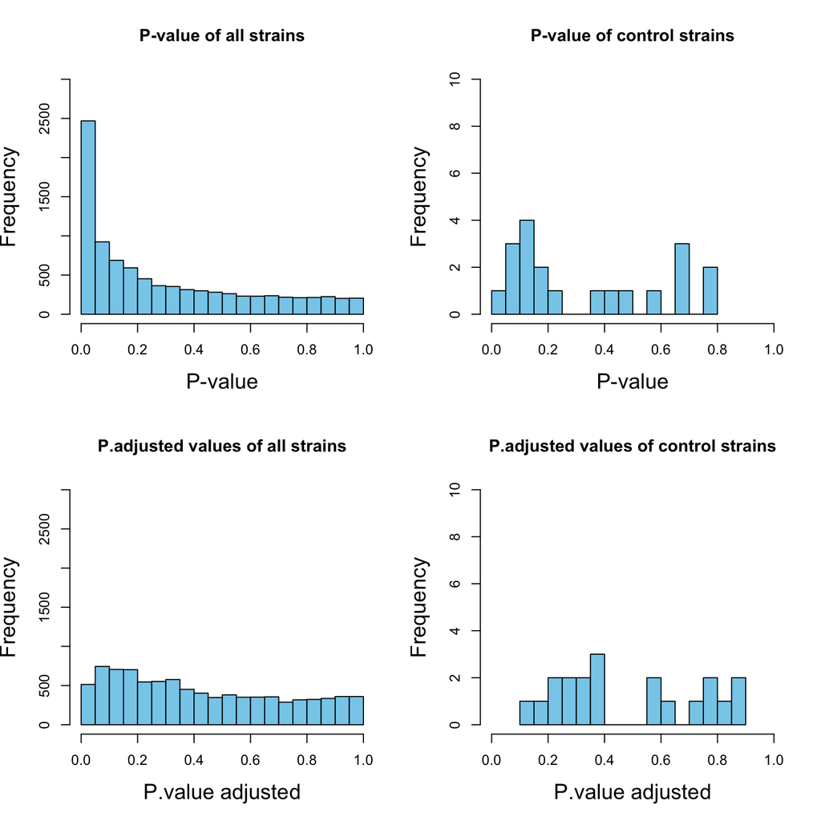

Figure 6 (Fig S9 in Manuscript): P-value diagnostic by histogram, Method 3

#### P-VALUE DISGNOSTICS FOR METHOD 4

NUMBER OF SIGNIFICANT STRAINS

```r
length(Analysis_Final_3$P.value_M4[which(Analysis_Final_3$P.value_M4<=0.05)])
```

```
## [1] 3663
```

```r
length(Analysis_Final_3$P.adjusted_M4[which(Analysis_Final_3$P.adjusted_M4<=0.05)])
```

```
## [1] 2212
```

```r
length(Analysis_Final_3$P.value_M4[which(Analysis_Final_3$P.value_M4<=0.1)])
```

```
## [1] 4545
```

```r
length(Analysis_Final_3$P.adjusted_M4[which(Analysis_Final_3$P.adjusted_M4<=0.1)])
```

```
## [1] 3306
```

P-VALUE DIAGNOSTICS BY **HISTOGRAM ANALYSIS**

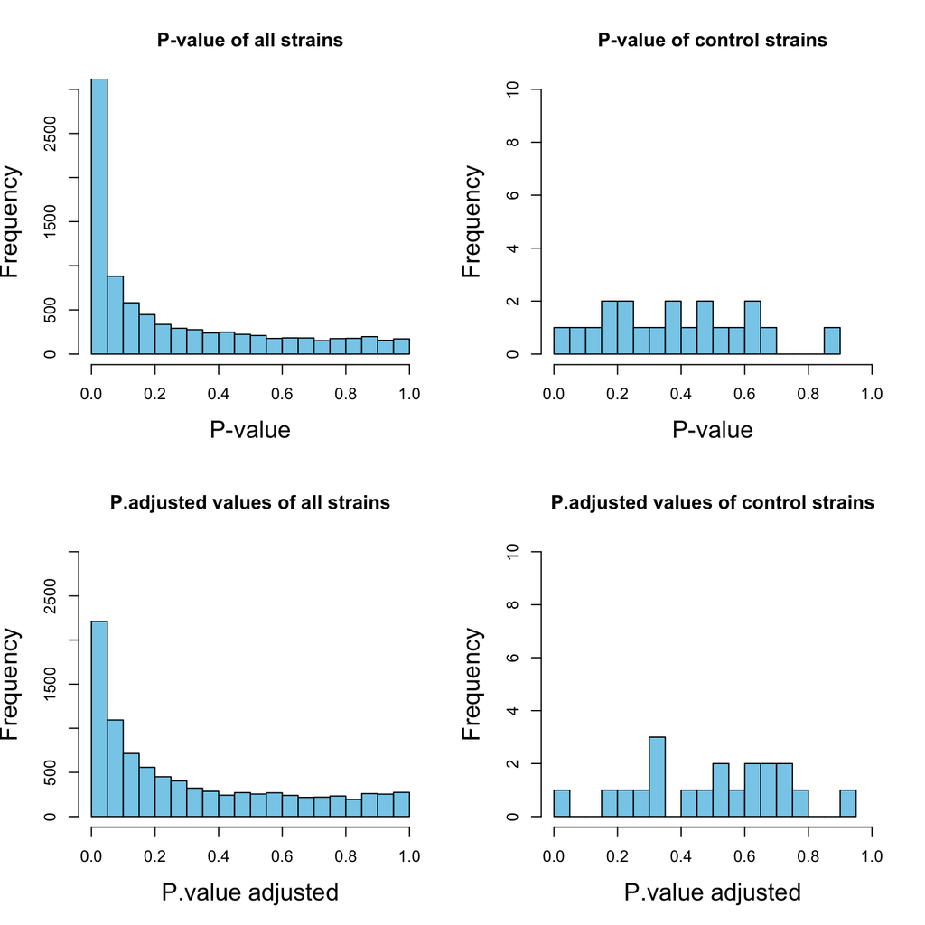

Figure 7: P-value diagnostic by histogram, Method 4

#### CONCLUSIONS METHOD 3

P.values generated by Method 3 can be corrected efficiently using the FDR method and after the correction the P.adjusted values have nearly equal distribution, which is indicative of a robust statistical outcome. Therefore Method 3 is a good statistical method for this dataset.

#### CONCLUSIONS METHOD 4

Although Method 4 is effective to identify candidates deviated most from the CRISPRi control means, but the FDR method is less effective on the generated P.value. Therefore, less efficient for the current dataset. Moreover, the CRISPRi control strains for some reason consistently displayed a slower growth under acetic acid compared to the mean of the population. This resulted a bias for method 4 in candidate selection.

### FINAL CONCLUSION FOR STATISTICAL ANALYSIS

Out of the 4 statistical methods evaluated, **METHOD 3** was the most promising method to identify the significant candidates. Therefore, for this study we considered the results of statistical Method 3 for further downstream analysis.

## SETTING THE STATISTICAL AND EFFECTSIZE THRESHOLD

Number of strains with **Adjusted P-value ≤ 0.1**

```r
length(Analysis_Final_3$P.adjusted_M3[which(Analysis_Final_3$P.adjusted_M3 <= 0.1)])
```

```
## [1] 1258
```

To avoid missing potential candidates just because of high variability among the replicates, we keep the adjusted P-value threshold less strict i.e. ≤ 0.1. In addition, we introduce an effect size threshold i.e. the phenotypic performance range of CRISPRi control strains.

- Estimating the Effect size threshold to identify acetic acid sensitive candidates

```r
max(Analysis_Final_3$LPI_GT_Mean_all[which(Analysis_Final_3$Control.gRNA==1)])
```

```
## [1] 0.165662
```

Therefore, any strain that have an **adjusted P-value ≤ 0.1** AND **mean LPI GT > 0.165662** will be considered **SENSITIVE to acetic acid**

- Estimating the Effect size threshold to identify acetic acid tolerant candidates

```r
min(Analysis_Final_3$LPI_GT_Mean_all[which(Analysis_Final_3$Control.gRNA==1)])
```

```
## [1] -0.03680838
```

Therefore, any strain that have an **adjusted P-value ≤ 0.1** AND **mean LPI GT < -0.03680838** will be considered **TOLERANT to acetic acid**

## EXTRACT THE ACETIC ACID TOLERANT STRAINS

- Extract the row index that satisfy the statistical (adjusted P-value ≤ 0.1) and effect size (mean LPI GT < -0.03680838) criterion for acetic acid tolerant candidates

```r
candidate_padj_0.1_FIT_M3 <- which((Analysis_Final_3$LPI_GT_Mean_all < -0.03680838 & Analysis_Final_3$P.adjusted_M3<= 0.1))
length(candidate_padj_0.1_FIT_M3)
```

```
## [1] 478
```

This gives **478 ACETIC ACID TOLERANT** strains

- Extract the row data of acetic acid tolerant strains

```r
Fit_M3_complete <- Analysis_Final_3[candidate_padj_0.1_FIT_M3, ]
Fit_M3_complete <- Fit_M3_complete[order(Fit_M3_complete$LPI_GT_Mean_all, decreasing = FALSE), ]
str(Fit_M3_complete)
```

```
## 'data.frame':    478 obs. of  103 variables:
##  $ gRNA_name             : chr  "RPN9-TRg-4" "RGL1-NRg-7" "RPN9-NRg-7" "POP3-NRg-5" ...
##  $ Seq                   : chr  "ACCCGCTCCCCGCTTTCATC" "GCTCTTGTTTAGTAGGCGTG" "ACCGGATGAAAGCGGGGAGC" "CAAATATCCGCCCTGGCAAT" ...
##  $ SOURCEPLATEID         : chr  "R2877.H.021" "R2877.H.002" "R2877.H.020" "R2877.H.022" ...
##  $ SOURCECOLONYCOLUMN    : int  1 3 7 19 4 3 18 7 1 3 ...
##  $ SOURCECOLONYROW       : chr  "B" "P" "N" "C" ...
##  $ GENE                  : chr  "RPN9" "RGL1" "RPN9" "POP3" ...
##  $ Control.gRNA          : int  0 0 0 0 0 0 0 0 0 0 ...
##  $ Location_1536         : chr  "C1" "AE5" "AA13" "E37" ...
##  $ CTRL_GT_RND1_R1       : num  0.07603 -0.05695 0.02247 -0.01067 0.00419 ...
##  $ CTRL_GT_RND1_R2       : num  0.08332 -0.06969 -0.02313 0.01964 0.00952 ...
##  $ CTRL_GT_RND1_R3       : num  0.16235 -0.00953 0.00817 0.06949 -0.03925 ...
##  $ CTRL_GT_RND2_R1       : num  -0.0229 -0.01756 0.08764 0.0332 0.00409 ...
##  $ CTRL_GT_RND2_R2       : num  0.01055 -0.01944 -0.0114 0.02561 0.00428 ...
##  $ CTRL_GT_RND2_R3       : num  -0.00635 -0.06164 0.0289 0.03377 -0.01342 ...
```

[output cut: 86 more lines]

## EXTRACT ALL CRISPRi TARGET GENES THAT INDUCED ACETIC ACID TOLERANCE

- Extract description of all genes (1617 genes) involved in this study from Saccharomyces Genome Database (SGD). A .csv file for this purpose is already exist in the **COMPILED_DATA** folder

**Gene Description Key file** :Gene_List_CRISPRi_lib.csv

```r
whole_Gene_list_Final <- read.csv("COMPILED_DATA/Gene_List_CRISPRi_lib.csv", na.strings = "", stringsAsFactors = FALSE)
rownames(whole_Gene_list_Final) <- whole_Gene_list_Final$LIB_ID
str(whole_Gene_list_Final)
```

```
## 'data.frame':    1617 obs. of  7 variables:
##  $ LIB_ID     : chr  "AAR2" "AAT1" "AAT2" "ABD1" ...
##  $ SGD_DB_ID  : chr  "S000000170" "S000001589" "S000004017" "S000000440" ...
##  $ SYS_ID     : chr  "YBL074C" "YKL106W" "YLR027C" "YBR236C" ...
##  $ GENE_SYM   : chr  "AAR2" "AAT1" "AAT2" "ABD1" ...
##  $ NAME       : chr  "A1-Alpha2 Repression" "Aspartate AminoTransferase" "Aspartate AminoTransferase" NA ...
##  $ PHENOTYPE  : chr  "Essential gene; conditional mutant is heat sensitive, loses viability at elevated temperature and displays elev"| __truncated__ "Non-essential gene; null mutant has a reduced respiratory growth rate and decreased competitive fitness on non-"| __truncated__ "Non-essential gen…
##  $ DESCRIPTION: chr  "Component of the U5 snRNP complex; required for splicing of U3 precursors; originally described as a splicing f"| __truncated__ "Mitochondrial aspartate aminotransferase; catalyzes the conversion of oxaloacetate to aspartate in aspartate an"| __truncated__ "Cytosolic asparta…
```

- Next, prepare a data.frame with descriptions of CRISPRi target genes that induced acetic acid **tolerance**. This file also include how many gRNAs per target gene induced the acetic acid tolerance.

```r
Fit_all_M3 <- data.frame(sort(table(Analysis_Final_3$GENE[candidate_padj_0.1_FIT_M3]), decreasing = TRUE))
y <- as.character(Fit_all_M3$Var1)
x <- whole_Gene_list_Final[y, ]
Fit_all_M3_description <- cbind(Fit_all_M3, x[, -1])
str(Fit_all_M3_description)
```

```
## 'data.frame':    370 obs. of  8 variables:
##  $ Var1       : Factor w/ 370 levels "PEP7","RPN9",..: 1 2 3 4 5 6 7 8 9 10 ...
##  $ Freq       : int  5 5 5 4 3 3 3 3 3 3 ...
##  $ SGD_DB_ID  : chr  "S000002731" "S000002835" "S000001899" "S000006069" ...
##  $ SYS_ID     : chr  "YDR323C" "YDR427W" "YFR003C" "YPL148C" ...
##  $ GENE_SYM   : chr  "PEP7" "RPN9" "YPI1" "PPT2" ...
##  $ NAME       : chr  "carboxyPEPtidase Y-deficient" "Regulatory Particle Non-ATPase" "Yeast Phosphatase Inhibitor" "Phosphopantetheine:Protein Transferase" ...
##  $ PHENOTYPE  : chr  NA "Non-essential gene; null mutant is sensitive to elevated temperatures, shows cell cycle arrest in metaphase, an"| __truncated__ NA NA ...
##  $ DESCRIPTION: chr  "Adaptor protein involved in vesicle-mediated vacuolar protein sorting; multivalent adaptor protein; facilitates"| __truncated__ "Non-ATPase regulatory subunit of the 26S proteasome; similar to putative proteasomal subunits in other species;"| __truncated__ "Regulatory subuni…
```

```r
nrow(Fit_all_M3_description)
```

```
## [1] 370
```

This gives **370** CRISPRi target genes that induced acetic acid **TOLERANCE**

## EXTRACT THE ACETIC ACID SENSITIVE STRAINS

- First identify strains that grew well in Basal condition but did not grow or less than three (out of six) replicates managed to grow under acetic acid stress. We will call these strains as **SUPER SENSITIVE**. P-value estimation for these strains were not possible or was not performed as n was ≤ 2.

```r
super_sen_M3 <- Analysis_Final_3[which(!is.na(Analysis_Final_3$CTRL_GT_Mean_all)
                                       &(Analysis_Final_3$n_LPI<3)
                                       &(
                                         is.na(Analysis_Final_3$LPI_GT_Mean_all)
                                         |(Analysis_Final_3$LPI_GT_Mean_all> 0.165662)
                                       )
), ]
nrow(super_sen_M3)
```

```
## [1] 17
```

This gives **17 ACETIC ACID SUPER SENSITIVE** strains

```r
candidate_padj_0.1_SEN_M3 <- which((Analysis_Final_3$LPI_GT_Mean_all > 0.165662 & Analysis_Final_3$P.adjusted_M3<= 0.1))
length(candidate_padj_0.1_SEN_M3)
```

```
## [1] 481
```

This gives **481 ACETIC ACID SENSITIVE** strains.

- Extract the row data of acetic acid sensitive strains

```r
Sen_M3_complete <- rbind(super_sen_M3, Analysis_Final_3[candidate_padj_0.1_SEN_M3, ])
Sen_M3_complete <- Sen_M3_complete[order(Sen_M3_complete$LPI_GT_Mean_all, decreasing = TRUE), ]
nrow(Sen_M3_complete)
```

```
## [1] 498
```

In **TOTAL**, 481+17 = **498** strains displayed acetic acid **SENSITIVITY**

## EXTRACT ALL CRISPRi TARGET GENES THAT INDUCED ACETIC ACID SENSITIVITY

- Prepare a data.frame with descriptions of CRISPRi target genes that induced acetic acid **sensitivity**. This file also include how many gRNAs per target gene induced the acetic acid sensitivity.

```r
Sen_all_M3 <- data.frame(sort(table(c(Analysis_Final_3$GENE[candidate_padj_0.1_SEN_M3], super_sen_M3$GENE)), decreasing = TRUE))
y <- as.character(Sen_all_M3$Var1)
x <- whole_Gene_list_Final[y, ]
Sen_all_M3_description <- cbind(Sen_all_M3, x[, -1])
nrow(Sen_all_M3_description)
```

```
## [1] 367
```

This gives **367** CRISPRi target genes that induced acetic acid **SENSITIVITY**

## GO ANALYSIS

**Data preparation**

Extracting the SGD_ID for the unique genes in **Fit_all_M3** (see EXTRACT ALL CRISPRi TARGET GENES THAT INDUCED ACETIC ACID TOLERANCE)

```r
Fit_unique_M3 <- as.character(Fit_all_M3$Var1)
x <- whole_Gene_list_Final[Fit_unique_M3, ]
Fit_unique_M3_SGD_ID <- x$SGD_DB_ID
str(Fit_unique_M3_SGD_ID)
```

```
##  chr [1:370] "S000002731" "S000002835" "S000001899" "S000006069" ...
```

Extracting the SGD_ID for the unique genes in **Sen_all_M3** (see EXTRACT ALL CRISPRi TARGET GENES THAT INDUCED ACETIC ACID SENSITIVITY)

```r
Sen_unique_M3 <- as.character(Sen_all_M3$Var1)
x <- whole_Gene_list_Final[Sen_unique_M3, ]
Sen_unique_M3_SGD_ID <- x$SGD_DB_ID
str(Sen_unique_M3_SGD_ID)
```

```
##  chr [1:367] "S000003191" "S000003105" "S000006015" "S000001283" ...
```

Perform GO analysis with the above gene identifier sets in Saccharomyces genome database [link](https://www.yeastgenome.org/goTermFinder)

## DATA VISUALIZATION

Here we present the SCAN-O-MATIC data in graph and charts.

### PREREQUISITE PACKAGES

INSTALL

- **ggplot2**
- **reshape**
- **pheatmap**
- **wordcloud**

### SCATTER PLOT : CORRELATION BETWEEN LPI GT MEAN ROUND 1 and LPI GT MEAN ROUND 2

Scatterplot to display reproducibility of the two scan-o-matic screenings. The mean of the three LPI_GT replicates of each strain is plotted against X and Y axis for round1 and round2, respectively. The data of the CRISPRi control strains are indicated with green dots, acetic acid sensitive strains are indicated with red dots and acetic acid tolerant strains are indicated with blue dots. Data of all other strains are indicated with black dots.

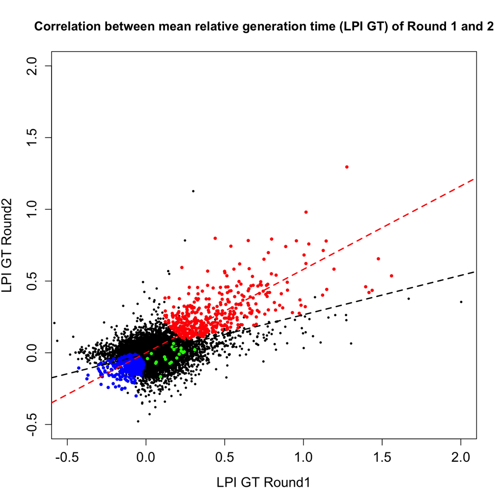

Figure 8 (Fig. 2A in Manuscript): DATA REPRODUCIBILITY

```r
summary(stats_LPI_GT_Mean_RND1vsRND2_M3)
```

```
##
## Call:
## lm(formula = LPI_GT_RND2_MEAN ~ LPI_GT_RND1_MEAN, data = Analysis_Final_3)
##
## Residuals:
##      Min       1Q   Median       3Q      Max
## -0.71004 -0.04877 -0.00146  0.04439  1.05360
##
## Coefficients:
##                   Estimate Std. Error t value Pr(>|t|)
## (Intercept)      -0.009341   0.001014  -9.215   <2e-16 ***
## LPI_GT_RND1_MEAN  0.274544   0.005532  49.631   <2e-16 ***
## ---
## Signif. codes:  0 '***' 0.001 '**' 0.01 '*' 0.05 '.' 0.1 ' ' 1
##
## Residual standard error: 0.0886 on 8832 degrees of freedom
##   (244 observations deleted due to missingness)
## Multiple R-squared:  0.2181, Adjusted R-squared:  0.218
## F-statistic:  2463 on 1 and 8832 DF,  p-value: < 2.2e-16
```

```r
cor(Analysis_Final_3$LPI_GT_RND1_MEAN,
    Analysis_Final_3$LPI_GT_RND2_MEAN,
    method = "pearson",
    use = "complete.obs")
```

```
## [1] 0.4669872
```

The linear regression fitting model (**black dashed line**) for the data of all strains together gave a co-efficient of determination i.e. **R<sup>2</sup> = 0.22** and Pearson correlation coefficient **r = 0.47**

```r
summary(stats_LPI_GT_Mean_RND1vsRND2_M3_selected)
```

```
##
## Call:
## lm(formula = LPI_GT_RND2_MEAN[c(candidate_padj_0.1_SEN_M3, candidate_padj_0.1_FIT_M3)] ~
##     LPI_GT_RND1_MEAN[c(candidate_padj_0.1_SEN_M3, candidate_padj_0.1_FIT_M3)],
##     data = Analysis_Final_3)
##
## Residuals:
##      Min       1Q   Median       3Q      Max
## -0.40299 -0.05268 -0.00899  0.03756  0.55375
##
## Coefficients:
##                                                                           Estimate
## (Intercept)                                                               0.000213
## LPI_GT_RND1_MEAN[c(candidate_padj_0.1_SEN_M3, candidate_padj_0.1_FIT_M3)] 0.581230
##                                                                           Std. Error
## (Intercept)                                                                 0.003588
## LPI_GT_RND1_MEAN[c(candidate_padj_0.1_SEN_M3, candidate_padj_0.1_FIT_M3)]   0.010154
##                                                                           t value
## (Intercept)                                                                 0.059
## LPI_GT_RND1_MEAN[c(candidate_padj_0.1_SEN_M3, candidate_padj_0.1_FIT_M3)]  57.240
##                                                                           Pr(>|t|)
## (Intercept)                                                                  0.953
## LPI_GT_RND1_MEAN[c(candidate_padj_0.1_SEN_M3, candidate_padj_0.1_FIT_M3)]   <2e-16
##
## (Intercept)
## LPI_GT_RND1_MEAN[c(candidate_padj_0.1_SEN_M3, candidate_padj_0.1_FIT_M3)] ***
## ---
## Signif. codes:  0 '***' 0.001 '**' 0.01 '*' 0.05 '.' 0.1 ' ' 1
##
## Residual standard error: 0.09715 on 872 degrees of freedom
##   (85 observations deleted due to missingness)
## Multiple R-squared:  0.7898, Adjusted R-squared:  0.7896
## F-statistic:  3276 on 1 and 872 DF,  p-value: < 2.2e-16
```

```r
cor(Analysis_Final_3$LPI_GT_RND1_MEAN[c(candidate_padj_0.1_SEN_M3, candidate_padj_0.1_FIT_M3)],
    Analysis_Final_3$LPI_GT_RND2_MEAN[c(candidate_padj_0.1_SEN_M3, candidate_padj_0.1_FIT_M3)],
    method = "pearson",
    use = "complete.obs")
```

```
## [1] 0.8887079
```

The linear regression fitting model (**red dashed line**) of the acetic acid sensitive and tolerant strain’s data gave a R<sup>2</sup> value of **0.79** and Pearson correlation coefficient **r= 0.89** .

### SCATTER PLOT LSC GT (IN BASAL CONDITION) VS LPI_GT

Scatterplot showing the relative generation time of each CRISPRi strains in basal condition in X-axis [Log Strain Co-efficient (LSC) of generation time (GT)] and relative generation time under acetic acid stress condition (150mM Acetic acid) compared to control condition in Y-axis (LPI_GT). Each point indicates the mean of all the replicates (n=6). For some acetic acid sensitive strains (198), the number of replicates are between 3-5 (n=3 for 135; n=4 for 16; n=5 for 47) as not all replicates managed to grow on the acetic acid stress condition. The data of the CRISPRi control strains are indicated with the green dots. Based on our statistical analysis, strains that have FDR adjusted P-values ≤ 0.1 and mean LPI_GT > 0.165 (maximum LPI_GT of CRISPRi control strains) are designated as acetic acid sensitive strains ( represented by red dots). Strains that have FDR adjusted P-values ≤ 0.1 and mean LPI_GT < -0.037 (minimum LPI_GT of CRISPRi control strains) are designated as acetic acid tolerant(blue dots). The LPI_GT threshold is indicated with a gray dashed line. Data of strains that falls outside the adjusted P-value and LPI_GT threshold, are indicated with black dots.

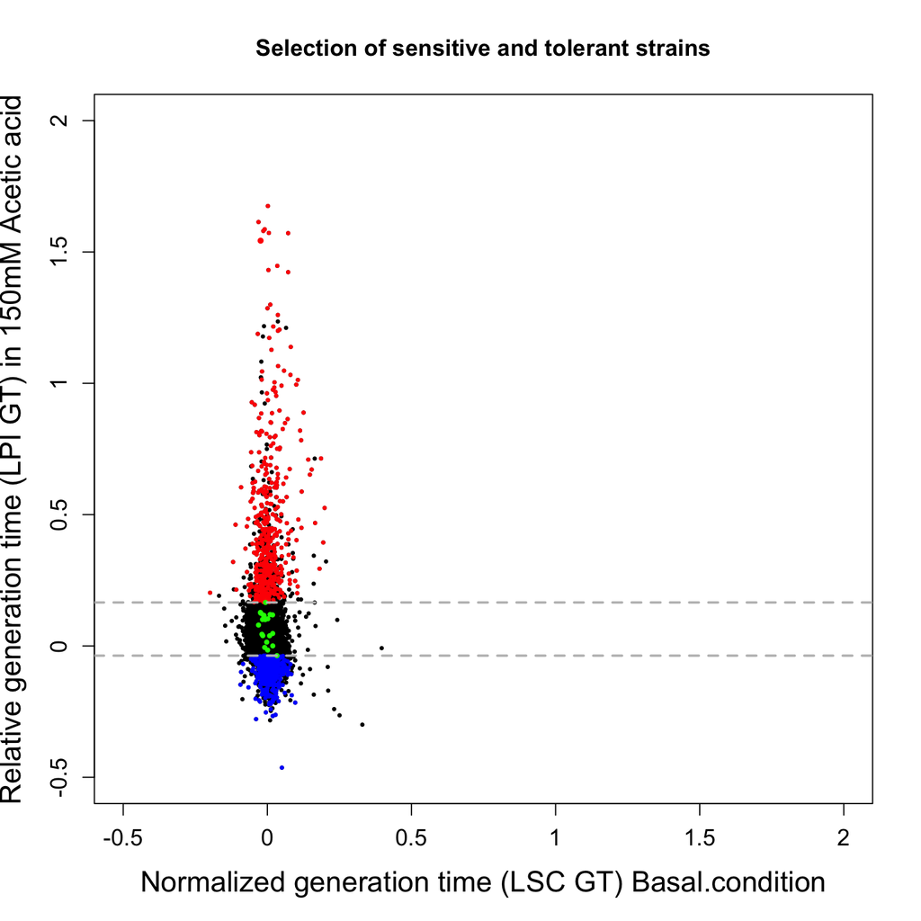

Figure 9 (Fig. 2C in Manuscript): Normalized generation time (LSC GT) of strains in Basal condition vs Relative generation time (LPI GT) of strains in acetic acid condition compared to basal condition

### VIOLIN PLOT

Violin-plots display the spread and the distribution of the LPI GT data for all CRISPRi strains (ALL), and LPI_GT values of CRISPRi control strains

- Preparing a dataset for violin plot of **LPI GT<sub>All_strains</sub>**, **LPI GT<sub>Control_strains</sub>**

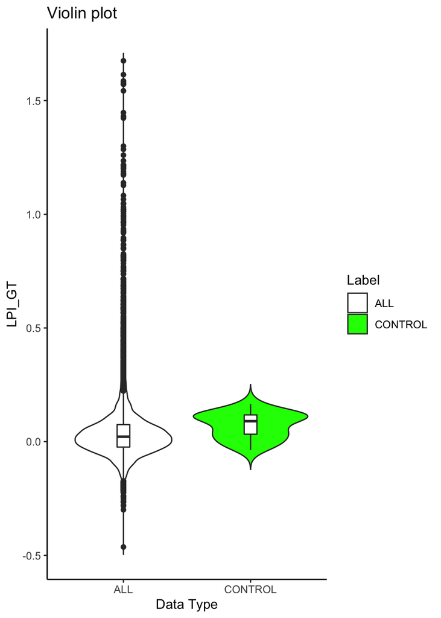

Figure 10 (Fig. 2C INSET, in Manuscript): Violin-plots display the spread and the distribution of the LPI GT data

```r
Violin_LPI_Mean_M3 <- data.frame()
R <- length(which((Analysis_Final_3$Control.gRNA==0)
                  &(!is.na(Analysis_Final_3$LPI_GT_Mean_all))
))
Violin_LPI_Mean_M3[1:R, 1] <- Analysis_Final_3$LPI_GT_Mean_all[which((Analysis_Final_3$Control.gRNA==0)
                                                                     &(!is.na(Analysis_Final_3$LPI_GT_Mean_all)))]
Violin_LPI_Mean_M3[1:R, 2] <- "ALL"
R2 <- length(which(Analysis_Final_3$Control.gRNA==1))
Violin_LPI_Mean_M3[(R+1):(R+R2), 1] <- Analysis_Final_3$LPI_GT_Mean_all[which(Analysis_Final_3$Control.gRNA==1)]
Violin_LPI_Mean_M3[(R+1):(R+R2), 2] <- "CONTROL"
colnames(Violin_LPI_Mean_M3)[1:2] <- c("Mean", "Label")
```

### WORDCLOUD

We display gene names that are highly represented within the fit and the sensitive strains, i.e. CRISPRi targeting of these genes by multiple gRNA displayed the tolerant / sensitive phenotype. The CRISPRi repression of a gene vs the obtained phenotype relationship is more reliable for those highly represented genes.

- WORD CLOUD for the acetic acid **TOLERANT** strains

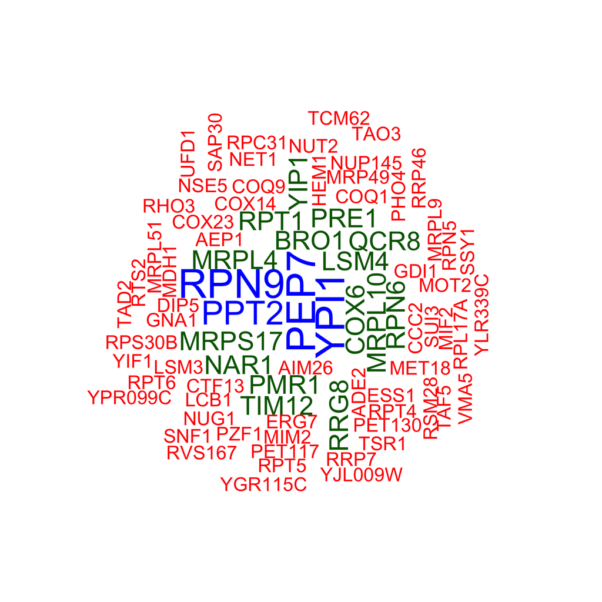

Figure 11: Wordcloud for CRISPRi gene targets of acetic acid tolerant strains

- WORD CLOUD for the acetic acid **SENSITIVE** strains

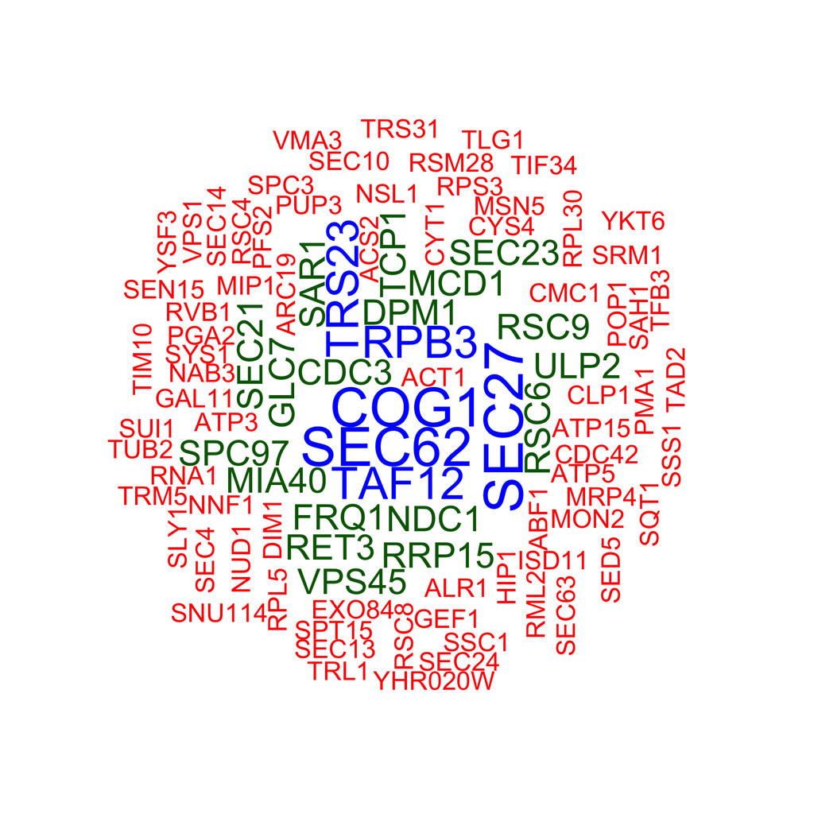

Figure 12: Wordcloud for CRISPRi gene targets of acetic acid sensitive strains

### HISTOGRAM

#### **STRAINS/GENE** AND **gRNA DISTANCE FROM TSS**

First assigning rownames as the gRNA names in the **Analysis_Final_3** data.frame

```r
row.names(Analysis_Final_3) <- Analysis_Final_3$gRNA_name
```

Next, for this graph we fetch some additional information from a .CSV file available as supplementary in smith et al., 2017. The file is also available in our COMPILED_DATA folder

**Supplementary data from smith et al., 2017** : smith_YEPGdata.csv

```r
Smith_Yepg_data <- read.csv("COMPILED_DATA/smith_YEPGdata.csv", na.strings = "")
str(Smith_Yepg_data)
```

```
## 'data.frame':    8939 obs. of  28 variables:
##  $ ORF                       : chr  "YBL074C" "YBL074C" "YBL074C" "YBL074C" ...
##  $ gRNA_targeting_seq        : chr  "CCAGCGATAAGGAGGATCTT" "TGTGTCCTTTCTTCATCTCT" "AAAAGGAAAAAGTAATTAGG" "GTGAAAAGGAAAAAGTAATT" ...
##  $ Midpoint_TSS_dist         : int  -36 -135 -187 -190 -33 -90 -139 -178 -11 -15 ...
##  $ Norm_atac_seq_read_density: num  0.56 0.93 0.62 0.62 0.54 0.55 0.53 0.41 0.28 0.28 ...
##  $ Multiple_ORFs_Targeted    : int  0 0 0 0 0 0 1 1 0 0 ...
##  $ nearby_genes              : chr  NA NA NA NA ...
##  $ gene_name                 : chr  "AAR2" "AAR2" "AAR2" "AAR2" ...
##  $ guide_id                  : chr  "AAR2-NRg-3" "AAR2-NRg-4" "AAR2-TRg-15" "AAR2-TRg-16" ...
##  $ oligo_seq                 : chr  "GGGAGCTGCGATTGGCAGCCAGCGATAAGGAGGATCTTGTTTTAGAGCTAGAAATAGCAAG" "GGGAGCTGCGATTGGCAGTGTGTCCTTTCTTCATCTCTGTTTTAGAGCTAGAAATAGCAAG" "GGGAGCTGCGATTGGCAGAAAAGGAAAAAGTAATTAGGGTTTTAGAGCTAGAAATAGCAAG" "GGGAGCTGCGATTGGCAGGTGAAAAGGAAAAAGTAATTGTTTTAGAGCTAGAAATAGCAAG" ...
##  $ YPEG_._ATC1               : num  16.8 963.5 193.5 153.9 78.3 ...
##  $ YPEG_._ATC2               : num  15 1010.4 208.2 136.5 46.2 ...
##  $ YPEG_._ATC3               : num  14.3 896.3 268.5 123.7 34.5 ...
##  $ YPEG4                     : num  55.9 815.5 447.3 276.6 133.9 ...
##  $ YPEG5                     : num  54 577 427 450 159 ...
##  $ YPEG6                     : num  60.3 722.8 311.5 312.5 91.6 ...
##  $ YPD_._ATC7                : num  28.3 687.2 349.5 258.9 111.6 ...
##  $ YPD_._ATC8                : num  29.1 560.2 376.3 199.9 88.7 ...
##  $ YPD_._ATC9                : num  54.4 816.7 338.7 227.5 124.8 ...
##  $ YPD10                     : num  11.5 639 604.1 405.4 121.7 ...
##  $ YPD11                     : num  46.7 688 528.5 380.2 141.8 ...
##  $ YPD12                     : num  57 809 479 213 153 ...
##  $ Pool                      : int  2 2 2 2 1 2 1 1 1 1 ...
##  $ Log2_YPEG                 : num  -1.884 0.441 -0.823 -1.327 -1.276 ...
##  $ Log2_YPD                  : num  -0.043 -0.0491 -0.598 -0.5412 -0.3587 ...
##  $ YPEG_filter_25            : int  1 1 1 1 1 1 1 0 1 1 ...
##  $ YPD_filter_25             : int  1 1 1 1 1 1 1 0 1 1 ...
##  $ ORF_Category              : chr  "Essential" "Essential" "Essential" "Essential" ...
##  $ RNA_structure.Kcal.Mol.   : num  -60.6 -56.8 -50.5 -55.3 -56.4 -52.7 -54.6 -57.7 -60.7 -54.1 ...
```

Out of several columns, the most useful for this study will be,

- Column No: 3 i.e. **Midpoint_TSS_dist**
- Column No: 4 i.e. **Norm_atac_seq_read_density**
- Column No: 5 i.e. **Multiple_ORFs_Targeted**
- Column No: 6 i.e. **nearby_genes**

Extract only this four column in the Analysis_Final_3 data.frame

```r
for(i in 1:nrow(Analysis_Final_3)){
  x <- which(row.names(Analysis_Final_3)[i]==Smith_Yepg_data$guide_id)
  if(length(x)==0){
    Analysis_Final_3[i, 104:107] <- NA
  } else {
    Analysis_Final_3[i, 104:107] <- Smith_Yepg_data[x, 3:6]
  }
}
colnames(Analysis_Final_3)[104:107] <- colnames(Smith_Yepg_data)[3:6]
str((Analysis_Final_3)[104:107])
```

```
## 'data.frame':    9078 obs. of  4 variables:
##  $ Midpoint_TSS_dist         : int  -36 -135 -187 -190 -33 -90 -139 -178 -11 -15 ...
##  $ Norm_atac_seq_read_density: num  0.56 0.93 0.62 0.62 0.54 0.55 0.53 0.41 0.28 0.28 ...
##  $ Multiple_ORFs_Targeted    : int  0 0 0 0 0 0 1 1 0 0 ...
##  $ nearby_genes              : chr  NA NA NA NA ...
```

Estimate the gRNA frequency

```r
gRNA_Freq <- data.frame(sort(table(Analysis_Final_3$GENE), decreasing = TRUE))
```

Plot the graphs

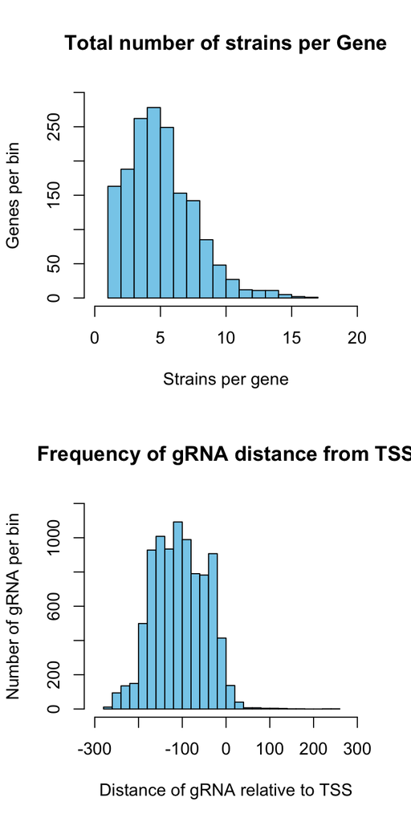

Figure 13: Histogram of number of strains per target gene in the CRISPRi library (TOP PANEL). Histogram of gRNA distance from Transcription starting site of the Genes (BOTTOM PANEL)

#### NORMALIZED GENERATION TIME (LSC GT) IN BASAL AND UNDER ACETIC ACID STRESS

First the LSC GT mean under acetic acid stress was recalculated for all the strains excluding the missing values

```r
for(i in 1:nrow(Analysis_Final_3)){
  test1 <- t(Analysis_Final_3[i, 22:27])
  x1 <- sum(!is.na(test1[, 1]))
  AA_GT_Mean_temp <- mean(test1[which(!is.na(test1[, 1]))])
  Analysis_Final_3[i, 32] <- AA_GT_Mean_temp
}
```

Plot the histogram

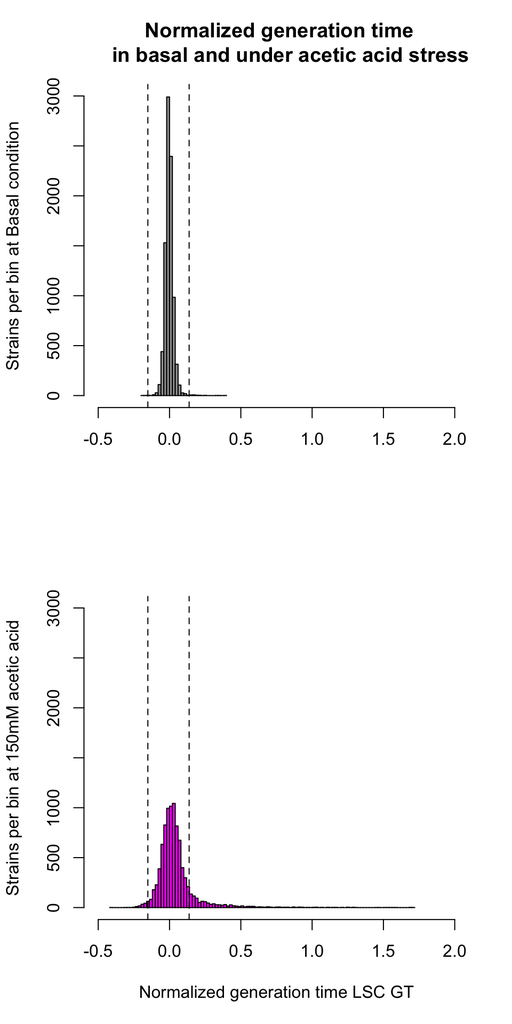

Figure 14 (fig. 2B in manuscript): Histogram to display strains growth in Basal condition (TOP PANEL). Histogram to display strains growth at 150mM of acetic acid (BOTTOM PANEL)

# BIOSCREEN LIQUID MICRO-CULTIVATION ANALYSIS

The results from Scan-o-matic phenomics were validated in liquid microcultivation growth experiment in bioscreen

## ATC TITRATION DATA ANALYSIS

### DATA PREPARATION FOR ATC DOSAGE RESPONSE

- Compiled Data Import: The ATc titration data is available in compiled form in the COMPILED_DATA folder

**ATc titration data compiled** : ATc_liq_titer_data.csv

```r
Atc_liq_data <- read.csv("COMPILED_DATA/ATc_liq_titer_data.csv", na.strings = "NaN", header = TRUE)
str(Atc_liq_data)
```

```
## 'data.frame':    80 obs. of  9 variables:
##  $ Well_No          : int  9 19 29 39 49 59 69 79 89 99 ...
##  $ gRNA_name        : chr  "ACT1-NRg-5" "ACT1-NRg-5" "ACT1-NRg-5" "ACT1-NRg-5" ...
##  $ Atc_concentration: num  0 0.25 1 2 3 5 7.5 10 15 25 ...
##  $ Lag_R1           : num  5.95 5.81 5.89 2.87 3.95 ...
##  $ GT_R1            : num  1.96 2.03 2.16 3.9 5.06 ...
##  $ Yield_R1         : num  2.98 3.17 2.77 1.42 1.03 ...
##  $ Lag_R2           : num  5.53 5.69 5.49 3.62 3.97 ...
##  $ GT_R2            : num  2 2.02 2.17 4.59 4.88 ...
##  $ Yield_R2         : num  2.87 3.02 2.96 1.21 1.05 ...
```

Note that in liquid experiment, three phenotypes were estimated i.e. growth **LAG** phase, **GENERATION TIME** and growth biomass **YIELD**

- Extract CRISPRi control strain (CC23) data

```r
Atc_liq_cc23 <- Atc_liq_data[which(Atc_liq_data$gRNA_name=="Ctrl-CC23"), ]
```

- Extract additional information such as the strain’s gRNA names and ATc concentrations used for titration

```r
uniq_gRNA <- unique(Atc_liq_data$gRNA_name)
uniq_conc <- unique(Atc_liq_data$Atc_concentration)
```

- Data transformation (log)

```r
Atc_liq_data[, 10:15] <- log(Atc_liq_data[, 4:9])
```

- Estimate Normalized growth (LSC) for **LAG** , **GENERATION TIME** and **YIELD**

To determine the normalized growth or Log Strain Co-efficient (LSC) values, we use the data of the control strain CC23. Substracting the log transformed growth phenotypes of CC23 from the log transformed phenotypes of the strains in the respective concentrations of ATc generates the log strain coefficients or LSC values at that condition for each phenotypes.

```r
for(i in 1:length(uniq_gRNA)){
  for(j in 1:length(uniq_conc)){
    Atc_liq_data[which(Atc_liq_data$gRNA_name==uniq_gRNA[i]&
                         Atc_liq_data$Atc_concentration==uniq_conc[j]), 16:21] <-
      Atc_liq_data[which(Atc_liq_data$gRNA_name==uniq_gRNA[i]&
                           Atc_liq_data$Atc_concentration==uniq_conc[j]), 10:15] -
      Atc_liq_data[which(Atc_liq_data$gRNA_name=="Ctrl-CC23"&
                           Atc_liq_data$Atc_concentration==uniq_conc[j]), 10:15]
  }
}
```

- Estimate the Mean and Standard deviation of the LSC values for each phenotype

```r
for(i in 1:nrow(Atc_liq_data)){
  Atc_liq_data[i, 22] <- mean(as.numeric(Atc_liq_data[i, c(16, 19)][which(!is.na(Atc_liq_data[i, c(16, 19)]))]))
  Atc_liq_data[i, 23] <- sd(as.numeric(Atc_liq_data[i, c(16, 19)][which(!is.na(Atc_liq_data[i, c(16, 19)]))]))
  Atc_liq_data[i, 24] <- mean(as.numeric(Atc_liq_data[i, c(17, 20)][which(!is.na(Atc_liq_data[i, c(17, 20)]))]))
  Atc_liq_data[i, 25] <- sd(as.numeric(Atc_liq_data[i, c(17, 20)][which(!is.na(Atc_liq_data[i, c(17, 20)]))]))
  Atc_liq_data[i, 26] <- mean(as.numeric(Atc_liq_data[i, c(18, 21)][which(!is.na(Atc_liq_data[i, c(18, 21)]))]))
  Atc_liq_data[i, 27] <- sd(as.numeric(Atc_liq_data[i, c(18, 21)][which(!is.na(Atc_liq_data[i, c(18, 21)]))]))
}
```

- Assign new column names

```r
colnames(Atc_liq_data)[10:15] <- paste0("log_", colnames(Atc_liq_data)[4:9])
colnames(Atc_liq_data)[16:21] <- paste0("LSC_", colnames(Atc_liq_data)[4:9])
colnames(Atc_liq_data)[22:23] <- paste0(c("Mean_", "SD_"), "LSC_Lag")
colnames(Atc_liq_data)[24:25] <- paste0(c("Mean_", "SD_"), "LSC_GT")
colnames(Atc_liq_data)[26:27] <- paste0(c("Mean_", "SD_"), "LSC_Yield")
```

### ATc DOSAGE RESPONSE VISUALIZATION BY SCATTER-PLOT

First making a subset to trim the dataset and include data for only the following gRNA_names *ACT1-NRg-5*, *ACT1-NRg-8*, *SEC21-NRg-5*, *VPS1-TRg-1*. These gRNA’s previously showed to induce strong CRISPRi mediated repression that ultimately caused lethality or very poor growth. These strains were also used for the ATc titration on YNB agar plates by Qualitative Spot-Test Assay. We also display the performance of another CRISPRi control strain *Ctrl-CC11* just to display how it performed compared to other strains.

```r
name_gRNA_atc_titer <- c("ACT1-NRg-5", "ACT1-NRg-8", "Ctrl-CC11", "SEC21-NRg-5", "VPS1-TRg-1")
test <- data.frame()
Atc_titer_subset <- data.frame()
for(i in 1:length(name_gRNA_atc_titer)){
  test <- Atc_liq_data[which(Atc_liq_data$gRNA_name==name_gRNA_atc_titer[i]), ]
  Atc_titer_subset <- rbind(Atc_titer_subset, test)
}
```

- PLOT NORMALIZED LAG, GENERATION TIME AND YIELD

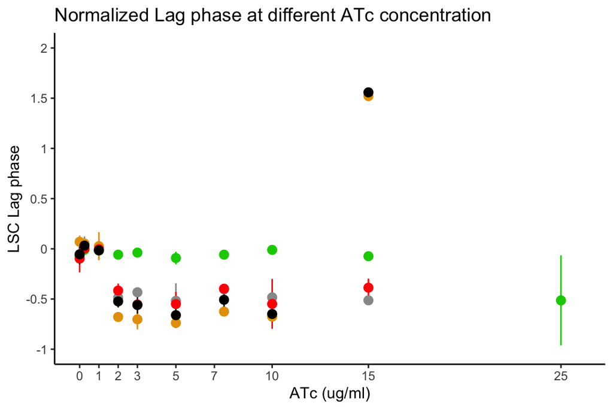

Figure 15 (fig. S1B in manuscript): Scatter plot to display ATC dosage response on Lag phase

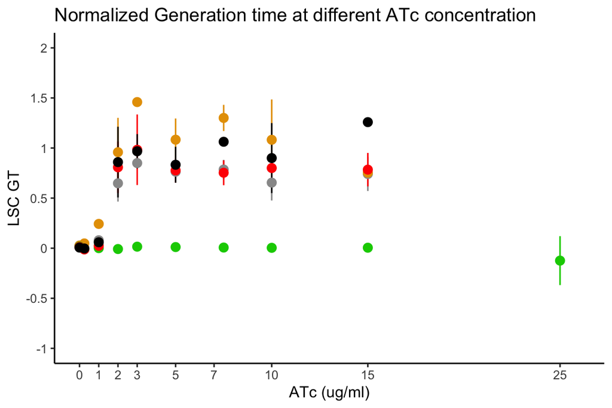

Figure 16 (fig. S1B in manuscript): Scatter plot to display ATC dosage response on Generation time

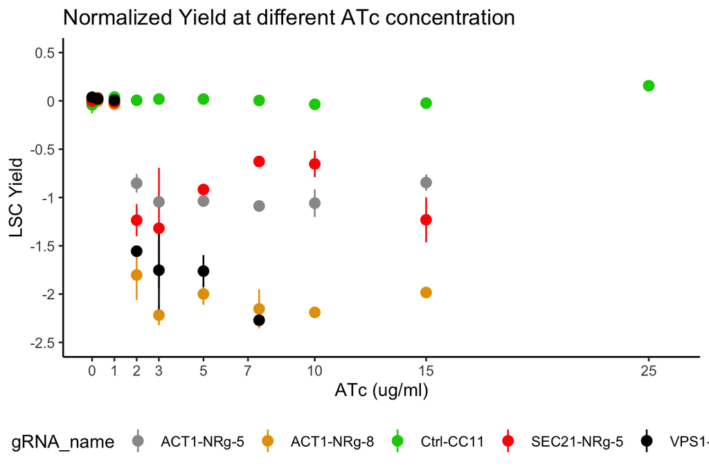

Figure 17 (fig. S1B in manuscript): Scatter plot to display ATC dosage response on Yield

## VALIDATION DATA ANALYSIS

In order to validate the acetic acid sensitivity or tolerance observed for the CRISPRi strains in the scan-o-matic screening, selected strains were grown in liquid YNB medium using the Bioscreen platform. The 48 most acetic acid sensitive and 50 most tolerant CRISPRi strains from the scan-o-matic analysis were selected for the validation. Moreover, all CRISPRi strains with gRNAs targeting any of the following 12 genes:*RPT4, RPN9, PRE4, MRPL10, MRPL4, SEC27, MIA40, VPS45, PUP3, VMA3, SEC62, COG1*, were included making a total of 176 strains that were grown together with 7 control strains in liquid medium. The strains were grown in liquid YNB medium (basal condition) and in liquid YNB medium supplemented with 125 or 150mM of acetic acid. For each strain, 3 independent replicates were included for each growth condition.